# Analyse et prévision des frais médicaux

Abdelghafour Ait bennassar, Salma Mounji

# Introduction

Pour réaliser leurs profit, les compagnies d’assurance doivent percevoir une prime plus élevée que le montant versé à l’assuré. Pour cette raison, les compagnies d’assurance investissent beaucoup de temps, d’efforts et d’argent dans la création de modèles qui prédit avec précision les coûts des soins de santé.  
Afin de remplir cette mission, nous allons dans un premier lieu analyser les facteurs qui influencent les charges médicaux et dans un second lieu essayer de construire un modèle adéquat et optimiser ses performances.

# Exploration des données

## Importation des données

```r
insurance_data <- read.csv("insurance.csv")
```

## Importation des outils nécessaires

```r
library(ggthemes)
library(tidyverse)
library(ggridges)
library(magrittr)
library(gridExtra)
library(patchwork)
library(inspectdf)
library(corrplot)
library(tidymodels)
library(car)
library(caret)
theme_set(theme_bw())
```

## Vue générale des données

```r
glimpse(insurance_data)
```

```
## Rows: 1,338
## Columns: 7
## $ age      <int> 19, 18, 28, 33, 32, 31, 46, 37, 37, 60, 25, 62, 23, 56, 27...
## $ sex      <chr> "female", "male", "male", "male", "male", "female", "femal...
## $ bmi      <dbl> 27.900, 33.770, 33.000, 22.705, 28.880, 25.740, 33.440, 27...
## $ children <int> 0, 1, 3, 0, 0, 0, 1, 3, 2, 0, 0, 0, 0, 0, 0, 1, 1, 0, 0, 0...
## $ smoker   <chr> "yes", "no", "no", "no", "no", "no", "no", "no", "no", "no...
## $ region   <chr> "southwest", "southeast", "southeast", "northwest", "north...
## $ charges  <dbl> 16884.924, 1725.552, 4449.462, 21984.471, 3866.855, 3756.6...
```

De nombreux facteurs qui influencent le montant qu’un assuré paye pour l’assurance médicale ne sont pas sous son contrôle. Néanmoins, il est bon d’avoir une compréhension de ce qu’ils sont. Voici quelques facteurs collectées par l’assurance, qu’on va étudier leurs influence sur le coût des primes d’assurance médicale :  
On dispose d’un dataset qui comporte 1338 observations sur 7 variables

- Age : l’âge des assurés (beneficiaires).
- Sex : sexe des assurés “male” ou “female”.
- bmi : indice de masse corporelle, fournissant une compréhension du corps, des poids relativement élevés ou faibles par rapport à la taille, indice objectif du poids corporel (kg / m ^ 2) utilisant le rapport taille / poids.
- children : nombre d’enfants couverts par l’assurance maladie / nombre de personnes à charge.
- smoker : est ce que l’assuré fume ou pas.
- region: la zone résidentielle du bénéficiaire aux États-Unis, nord-est, sud-est, sud-ouest, nord-ouest.
- charges: Frais médicaux individuels facturés par l’assurance maladie.

On va convertir les variables sex, children, region, smoker au type factor qui correspond aux variables catégorielles :

```r
insurance_data$sex %<>% as.factor()
insurance_data$children %<>% as.factor()
insurance_data$region %<>% as.factor()
insurance_data$smoker %<>% as.factor()
```

## Description des variables

```r
summary(insurance_data)
```

```
##       age            sex           bmi        children smoker
##  Min.   :18.00   female:662   Min.   :15.96   0:574    no :1064
##  1st Qu.:27.00   male  :676   1st Qu.:26.30   1:324    yes: 274
##  Median :39.00                Median :30.40   2:240
##  Mean   :39.21                Mean   :30.66   3:157
##  3rd Qu.:51.00                3rd Qu.:34.69   4: 25
##  Max.   :64.00                Max.   :53.13   5: 18
##        region       charges
##  northeast:324   Min.   : 1122
##  northwest:325   1st Qu.: 4740
##  southeast:364   Median : 9382
##  southwest:325   Mean   :13270
##                  3rd Qu.:16640
##                  Max.   :63770
```

## Discrétisation de la variable “bmi”

```r
insurance_data %<>% mutate(bmi_cat = cut(bmi,
  breaks = c(0, 18.5, 25, 30, 60),
  labels = c("Under Weight", "Normal Weight", "Overweight", "Obese")
))
```

- Under Weight: bmi<18.5
- Normal Weight: 18.5<bmi<25
- Overweight : 25=<bmi<30
- Obese: bmi>=30

## Description des variables catégorielles

```r
categ_cols <- insurance_data %>% select_if(~ class(.) == "factor")
for (col in names(categ_cols)) {
  # cat(col , ":")
  # print(round(prop.table(table(insurance_data[[col]])),digits=2))
  # cat("\n")
  t <- insurance_data %>%
    group_by_(col) %>%
    summarise(count = n()) %>%
    mutate(frequency = paste0(round(100 * count / sum(count), 0), "%")) %>%
    # gt::gt() %>%
    knitr::kable("html", align = "lcc") %>%
    kableExtra::kable_styling(full_width = F, position = "left") %>%
    print()
}
```

| sex | count | frequency |
| --- | --- | --- |
| female | 662 | 49% |
| male | 676 | 51% |

| children | count | frequency |
| --- | --- | --- |
| 0 | 574 | 43% |
| 1 | 324 | 24% |
| 2 | 240 | 18% |
| 3 | 157 | 12% |
| 4 | 25 | 2% |
| 5 | 18 | 1% |

| smoker | count | frequency |
| --- | --- | --- |
| no | 1064 | 80% |
| yes | 274 | 20% |

| region | count | frequency |
| --- | --- | --- |
| northeast | 324 | 24% |
| northwest | 325 | 24% |
| southeast | 364 | 27% |
| southwest | 325 | 24% |

| bmi_cat | count | frequency |
| --- | --- | --- |
| Under Weight | 21 | 2% |
| Normal Weight | 226 | 17% |
| Overweight | 386 | 29% |
| Obese | 705 | 53% |

## Proportions des modalités dans les variables catégorielles

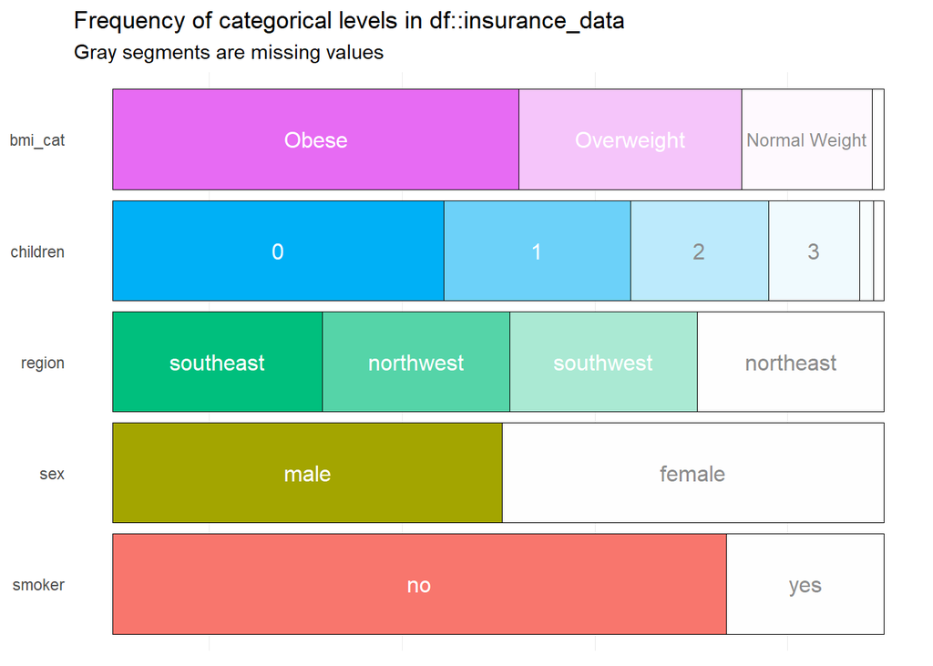

```r
show_plot(inspect_cat(insurance_data))
```

**Remarque :** Les individus ayant plus que 3 enfants et ceux en sous poids sont négligeables dans notre échantillon donc on va pas les prendre en compte pour la comparaison.

## Valeur manquantes

|  | count missing |
| --- | --- |
| age | 0 |
| sex | 0 |
| bmi | 0 |
| children | 0 |
| smoker | 0 |
| region | 0 |
| charges | 0 |
| bmi_cat | 0 |

le jeu de données ne contient aucune valeur manquante !

# Visualisation

## Matrice de corrélation

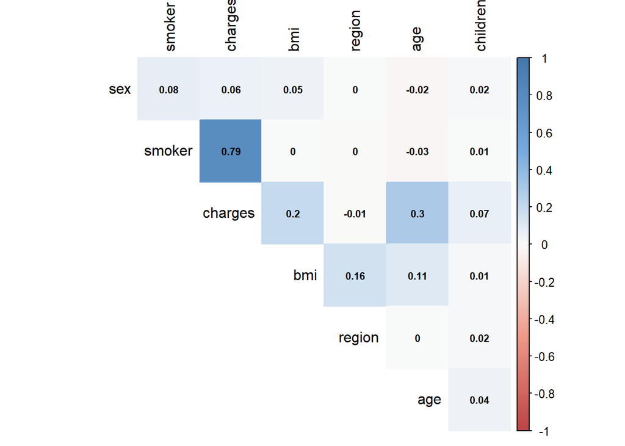

Les variables les plus corrélés avec les charges sont “smoker”, “age” et “bmi”.

## Visualisation des interactions entre les variables

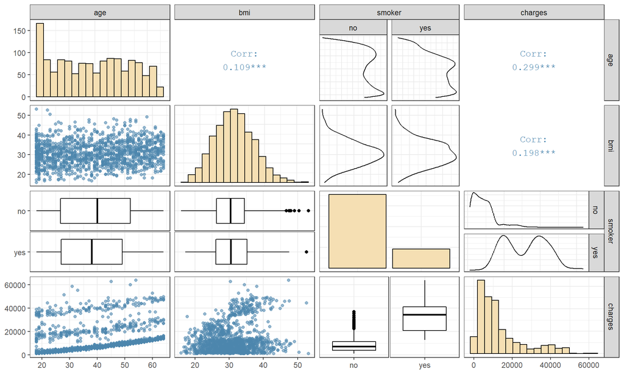

```r
#CPCOLS <- c("#617A8F", "#000000", "#B57779", "#FAFAFA", "#FFFFFF", "#FFFFFF")
# continuous:
# upper$continuous with lower$continuous String: ‘points’, ‘smooth’, ‘density’, ‘cor’, ‘blank’
# diag$continuous String: "densityDiag", "barDiag", "blankDiag"
# combo:
# upper$combo with lower$combo String: ‘box’, ‘dot’, ‘facethist’, ‘facetdensity’, ‘denstrip’, ‘blank’
# discrete:
# upper$discrete with lower$discrete String: ‘ratio’, ‘facetbar’, ‘blank’
# diag$discrete String: ‘barDiag’, ‘blankDiag’
CPCOLS <- c("#5B8888", "#bfd1d9", "#B57779", "#F4EDCA")

insurance_data %>%
  dplyr::select(age, bmi, smoker, charges) %>%
  GGally::ggpairs(
    lower = list(
      continuous = GGally::wrap("points", col = "#4c86ad",alpha=0.6),
      combo = GGally::wrap("box",
        fill = "white", col ="black"

      )
    ),
    upper = list(
      continuous = GGally::wrap("cor", col = "#4c86ad"),
      combo = GGally::wrap("facetdensity",
        col =
          "black"
      )
    ),
    diag = list(
      continuous = GGally::wrap(
        "barDiag",
        fill = "#f5dfb3", col ="black",
        bins = 18
      ),
      discrete = GGally::wrap("barDiag", fill = "#f5dfb3", col ="black")
    )
  )
```

## Distribution des charges

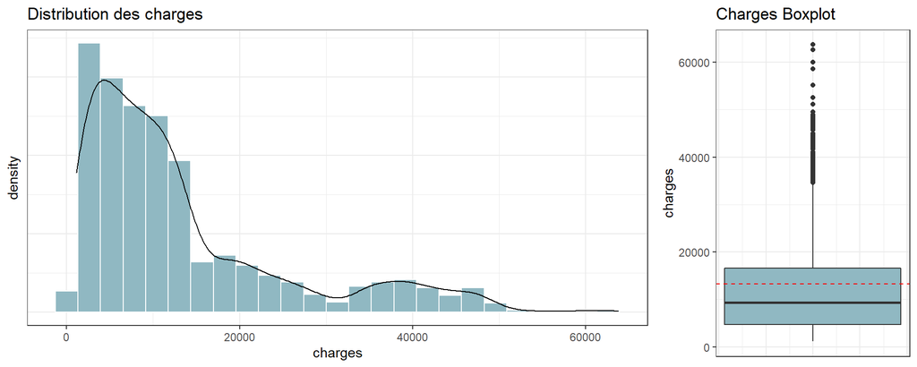

```r
p1 <- ggplot(data = insurance_data, aes(x = charges)) +
  geom_histogram(aes(y = ..density..),
    col = "white",
    bins = 25,
    fill = "#90b8c2"
  ) +
  geom_density() +
  labs(title = "Distribution des charges") +
  theme(
    axis.text.y = element_blank(),
    axis.ticks.y = element_blank()
  )
p2 <- ggplot(data = insurance_data, aes(y = charges)) +
  geom_boxplot(fill = "#90b8c2") +
  ggtitle("Charges Boxplot") +
  theme(
    axis.ticks.x = element_blank(),
    axis.text.x = element_blank()
  ) +
  geom_hline(aes(yintercept = mean(charges)),
    linetype = "dashed", col =
      "red"
  )
grid.arrange(p1, p2,
  ncol = 2, widths = c(5, 2)
)
```

La distribution des charges est biaisée à droite, on ne peut pas juger les valeurs aberrantes à partir de ce box plot. Donc on va effectuer une transformation logarithmique pour centraliser la distribution.

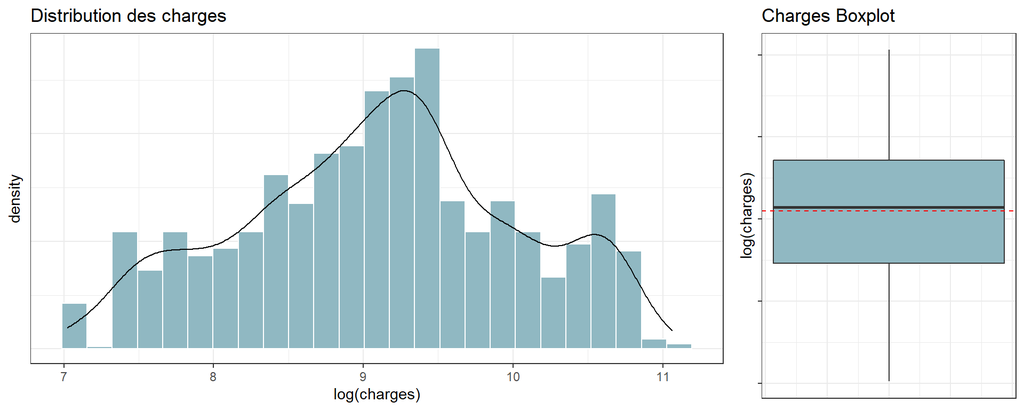

```r
p1 <- ggplot(data = insurance_data, aes(x = log(charges))) +
  geom_histogram(aes(y = ..density..),
    col = "white",
    bins = 25,
    fill = "#90b8c2"
  ) +
  geom_density() +
  labs(title = "Distribution des charges") +
  theme(
    axis.text.y = element_blank(),
    axis.ticks.y = element_blank()
  )
p2 <- ggplot(data = insurance_data, aes(y = log(charges))) +
  geom_boxplot(fill = "#90b8c2") +
  ggtitle("Charges Boxplot") +
  theme(
    axis.text.y = element_blank(),
    axis.ticks.x = element_blank(),
    axis.text.x = element_blank()
  ) +
  geom_hline(aes(yintercept = mean(log(charges))),
    linetype = "dashed", col =
      "red"
  )
grid.arrange(p1, p2,
  ncol = 2, widths = c(5, 2)
)
```

On peut maintenant assumer qu’il n’y a aucune anomalie.

## Interactions entre l’âge,les conditions de poids et le fait de fumer et leurs impact sur les charges médicales

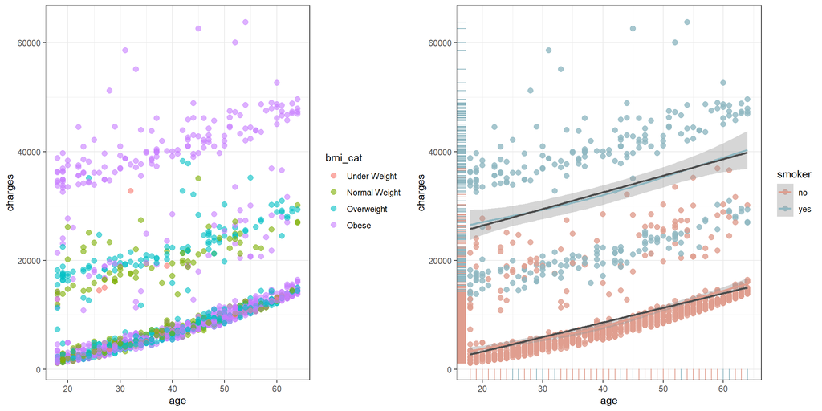

```r
p1 <- insurance_data %>%
  ggplot(aes(x = age, y = charges, col = bmi_cat)) +
  geom_point(alpha = 0.6, size = 2.5)

p2 <- insurance_data %>%
  ggplot(aes(x = age, y = charges, col = smoker)) +
  geom_point(alpha = 0.8,size = 2.5) +
  scale_color_manual(values = c("#e09e8f", "#90b8c2")) +
  geom_rug() +
  geom_smooth() +
  geom_smooth(
    data = filter(insurance_data, smoker == "yes"),
    col = "grey30",
    method = lm,
    se = FALSE
  ) +
  geom_smooth(
    data = filter(insurance_data, smoker == "no"),
    col = "grey30",
    method = lm,
    se = FALSE
  )

grid.arrange(p1, p2, nrow = 1)
```

Les charges sont liées à l’âge par une relation quasiment linéaire à trois niveaux :

- un premier groupe qui se caractérise par les charges les plus élevés, il se compose totalement des individus obèses et fumeurs.
- un second groupe qui se caractérise par les charges les plus faibles, il se compose totalement des individus non fumeurs et une distribution de bmi normale.
- et un 3ème groupe non homogène qui nécessite plus d’exploration.

On peut également constater que -pour les trois niveaux- plus les clients sont âgés, plus leurs charges sont élevés.

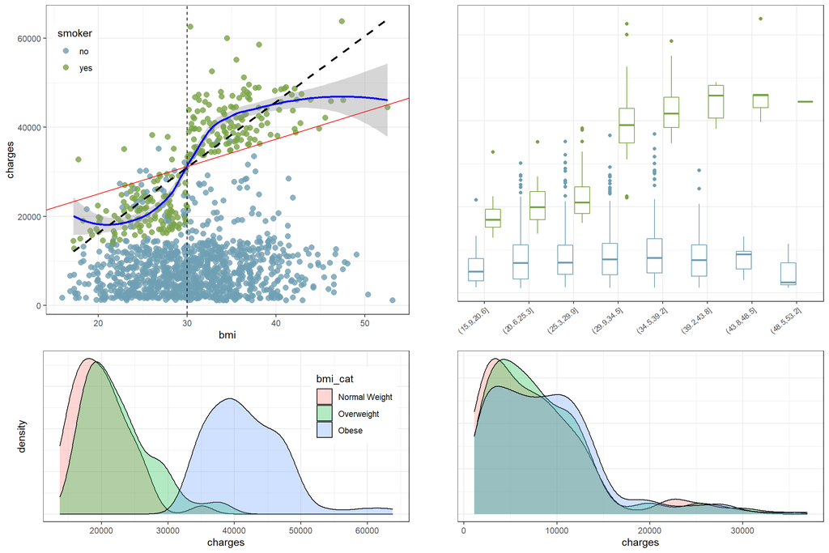

```r
p1 <- insurance_data %>%
  ggplot(aes(x = bmi, y = charges, col = smoker)) +
  geom_point(size = 2.5, alpha = 0.8) +
  scale_color_manual(values = c("#6f9fb3", "#79a346")) +
  theme(legend.position = c(0.08, 0.85)) +
  geom_smooth(
    data = filter(insurance_data, smoker == "yes"),
    col = "blue"
  ) +
  geom_smooth(
    data = filter(insurance_data, smoker == "yes"),
    col = "black",
    method = lm,
    se = FALSE,
    lty = "dashed"
  ) +
  geom_vline(aes(xintercept = 30), linetype = "dashed") +
  geom_abline(aes(intercept = 12800, slope = 615), col = "red")

p2 <- insurance_data %>%
  ggplot(aes(
    x = cut(bmi, breaks = 8),
    y = charges,
    col = smoker
  )) +
  geom_boxplot() +
  scale_color_manual(values = c("#6f9fb3", "#79a346")) +
  labs(x = "intervalles de bmi") +
  guides(col = FALSE) +
  labs(x = element_blank(), y = "\n\n") +
  theme(axis.text.x = element_text(
    size = 8,
    angle = 40,
    hjust = 1
  )) +
  theme(
    axis.text.y = element_blank(),
    axis.ticks.y = element_blank()
  )

p3 <- insurance_data %>%
  filter(smoker == "yes" & bmi_cat != "Under Weight") %>%
  ggplot(aes(x = charges, fill = bmi_cat)) +
  geom_density(alpha = 0.3) +
  scale_color_manual(values = c("#e09e8f", "#90b8c2","#6f9fb3")) +
  theme(
    axis.text.y = element_blank(),
    axis.ticks.y = element_blank()
  ) +
  theme(legend.position = c(0.85, 0.68)) +
  labs(y = "\ndensity\n")
p4 <- insurance_data %>%
  filter(smoker == "no" & bmi_cat != "Under Weight") %>%
  ggplot(aes(x = charges, fill = bmi_cat)) +
  geom_density(alpha = 0.3) +
  theme(
    axis.text.y = element_blank(),
    axis.ticks.y = element_blank()
  ) +
  guides(fill = FALSE) +
  labs(y = "\n\n")
gridExtra::grid.arrange(p1, p2, p3, p4, nrow = 2, heights = c(5, 3))
```

Pour les non fumeurs, l’obesité n’a aucun impact sur les charges.  
Par contre les fumeurs créent presque un nouveau nuage de points séparée des non-fumeurs qui se caractérise par la croissance des charges en fonction du bmi. ce nuage s’éleve fortement lorsque le seuil d’obesité est franchi (bmi=30): Le seuil maximal des charges des non obèses est identique au seuil minimal des charges des obèses.

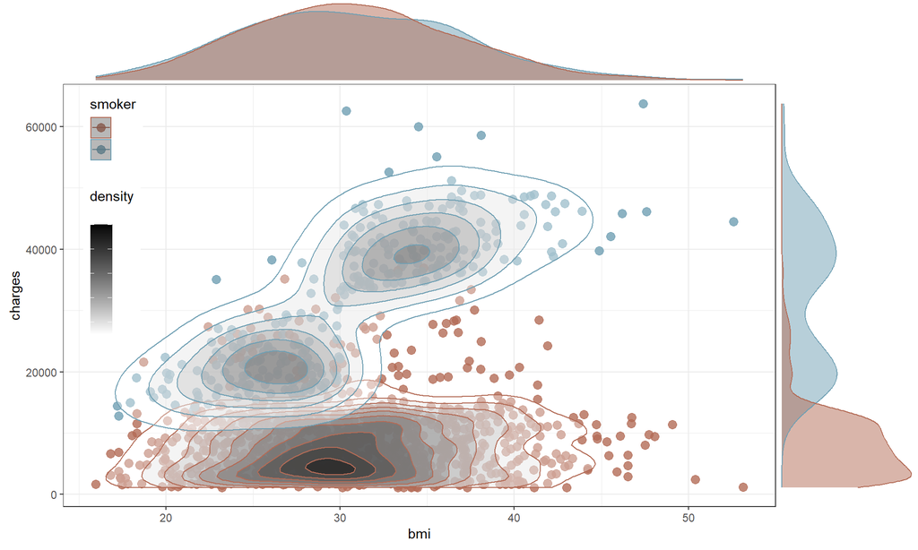

```r
p1 <- insurance_data %>%
  ggplot(aes(x = bmi, y = charges, col = smoker)) +
  geom_point(size = 3, alpha = 0.8) +
  scale_color_manual(values = c("#b36b56", "#6f9fb3")) +
  geom_density_2d() +
  stat_density_2d(aes(fill = ..level..), geom = "polygon", alpha = 0.35) +
  labs(fill = "density\n") +
  scale_fill_gradient(low = "white", high = "black") +
  theme(
    legend.position = c(0.07, 0.69),
    legend.text = element_blank()
  )
ggExtra::ggMarginal(p1, groupColour = TRUE, groupFill = TRUE)
```

```r
# ggExtra::ggMarginal(p1,type = "histogram", fill = "grey", col = "black")
```

On peut distinguer trois centres de densité :  
Le premier englobe tous les individus non fumeurs et se caractérise par des charges faible et une répartition normale de bmi. Le 2ème regroupe les individus fumeurs non obèses et ayant des charges relativement élevés.  
et le dernier rassemble les individus fumeurs et obèses ayant des charges très élevés.

## Création d’une nouvelle variable “Health”

On va créer une variable “health” qui distingue chacun de ces groupes observés :  
- “Obese smokers”  
- “Non obese smokers”  
- “Non smokers”

```r
insurance_data %<>%
  mutate(
    health = case_when(
      smoker == "yes" & bmi_cat == "Obese" ~ "Obese and smoker",
      smoker == "yes" & bmi_cat != "Obese" ~ "Non obese and smoker",
      smoker == "no" ~ "Non smoker"
    )
  )
insurance_data$health %<>% as.factor()
```

## Exploration de “Health”

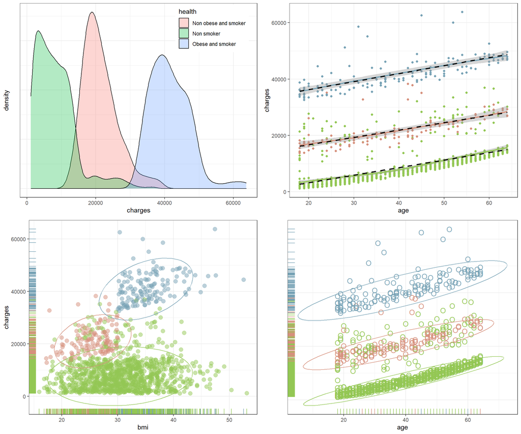

```r
p1 <- insurance_data %>%
  ggplot(aes(x = charges, fill = health)) +
  geom_density(alpha = 0.3) +
  theme(legend.position = c(0.81, 0.87)) +
  theme(
    axis.text.y = element_blank(),
    axis.ticks.y = element_blank()
  ) +
  labs(y = "density\n")
p2 <- insurance_data %>%
  ggplot(aes(y = charges, x = age, col = health)) +
  geom_point() +
  scale_color_manual(values = c("#d6907c","#93c754", "#77a2b5")) +
  geom_smooth() +
  geom_smooth(
    aes(group = health),
    col = "black",
    method = lm,
    se = FALSE,
    lty = "dashed"
  ) +
  guides(col = FALSE)
p3 <- insurance_data %>%
  ggplot(aes(x = bmi, y = charges, col = health)) +
  geom_point(size = 3, alpha = 0.5) +
  scale_color_manual(values = c("#d6907c","#93c754", "#77a2b5")) +
  stat_ellipse() +
  geom_rug() +
  guides(col = FALSE)
p4 <- insurance_data %>%
  ggplot(aes(x = age, y = charges, col = health)) +
  geom_point(
    size = 4,
    alpha = 0.9,
    shape = "O"
  ) +
  scale_color_manual(values = c("#d6907c","#93c754", "#77a2b5")) +
  stat_ellipse() +
  geom_rug() +
  guides(col = FALSE) +
  theme(
    axis.text.y = element_blank(),
    axis.ticks.y = element_blank()
  ) +
  labs(y = "\n\n")
grid.arrange(p1, p2, p3, p4, nrow = 2)
```

## L’impact du genre sur les frais médicaux

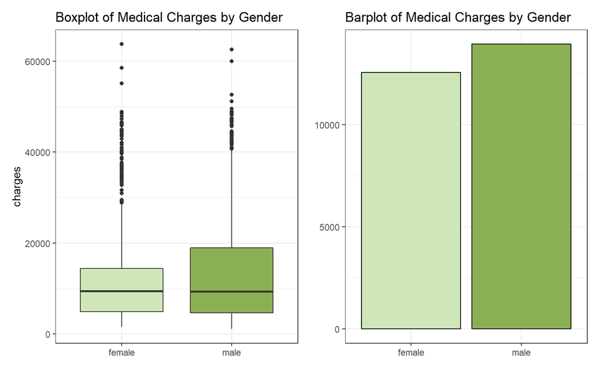

```r
p1 <- ggplot(data = insurance_data, aes(sex, charges)) +
  geom_boxplot(fill = c("#cfe6b8", "#8bb054")) +
  labs(x = element_blank()) +
  ggtitle("Boxplot of Medical Charges by Gender")

p2 <- ggplot(insurance_data, aes(reorder(sex, charges), charges)) +
  geom_bar(
    fill = c("#cfe6b8", "#8bb054"),
    col="black",
    position = "dodge",
    stat = "summary",
    fun = "mean"
  ) +
  labs(x = element_blank(), y = element_blank()) +
  ggtitle("Barplot of Medical Charges by Gender")
p1 + p2
```

On remarque que les frais médicaux sont plus élevés chez les hommes par rapport aux femmes  
On se demande si la majorité des fumeurs sont des hommes ?

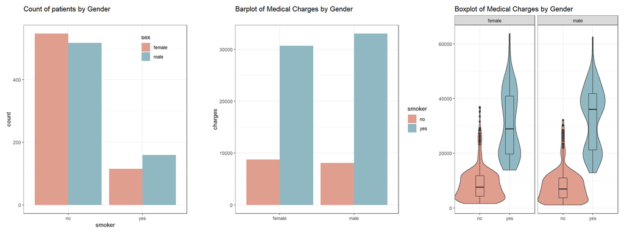

```r
p1 <- insurance_data %>%
  ggplot(aes(x = smoker, fill = sex)) +
  geom_bar(position = "dodge") +
  theme(legend.position = c(0.8, 0.88)) +
  ggtitle("Count of patients by Gender")+
  scale_fill_manual(values = c("#e09e8f", "#90b8c2"))
p2 <- insurance_data %>%
  ggplot(aes(sex, charges, fill = smoker)) +
  geom_bar(
    position = "dodge",
    stat = "summary",
    fun = "mean"
  ) +
  labs(x = element_blank(), y = "\n\n\ncharges") +
  ggtitle("Barplot of Medical Charges by Gender")+
  scale_fill_manual(values = c("#e09e8f", "#90b8c2"))
p3 <- insurance_data %>%
  ggplot(aes(y = charges, x = smoker, fill = smoker)) +
  geom_violin(width = 1.7) +
  geom_boxplot(width = 0.28) +
  guides(fill = FALSE) +
  labs(x = element_blank(), y = element_blank()) +
  ggtitle("Boxplot of Medical Charges by Gender") +
  scale_fill_manual(values = c("#e09e8f", "#90b8c2")) +
  facet_wrap(~sex)

p1 + p2 + p3
```

On peut maintenant confirmer notre supposition.  
et en comparent les feumeurs des deux genres, on trouve que la différence des frais médicaux entres les hommes et les femmes peut être expliquée par deux facteurs :

- Les hommes fument plus que les femmes (graphe 1)
- les charges chez les fumeurs sont plus élevée que les charges chez les fumeuses (graphe 2 & 3)

## Analyse régionale

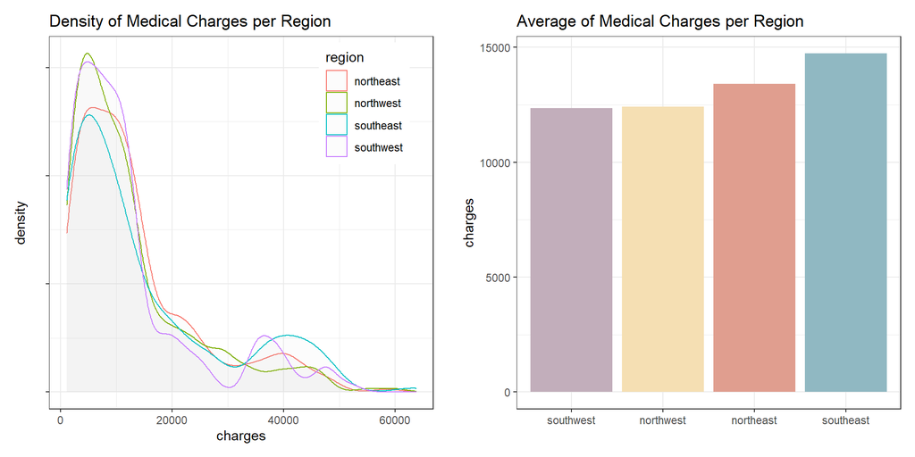

```r
p1 <- ggplot(insurance_data, aes(charges,col = region),col = c("#a6bbff" ,"#ffc99c" ,"#f5dfb3", "#e6a1bc")) +
  geom_density( fill = "grey", alpha = 0.05) +
  ggtitle("Density of Medical Charges per Region") +
  theme(legend.position = c(0.82, 0.82)) +
  theme(axis.text.y = element_blank()) +
  labs(y = "density\n")
p2 <- ggplot(insurance_data, aes(reorder(region, charges), charges)) +
  geom_bar(
    fill = c("#c2aebb" , "#f5dfb3","#e09e8f","#90b8c2"),
    position = "dodge",
    stat = "summary",
    fun = "mean"
  ) +
  labs(x = "", y = "\ncharges") +
  ggtitle("Average of Medical Charges per Region")
p1 + p2
```

On constate que les frais médicaux sont également distribués sur les régions avec une légère augmentation dans le sud-est. Cherchons la cause dérrière cette différence!

### Tableau de contingence

```r
cat("% de chaque chaque categorie de santé par région :\n")
```

```
## % de chaque chaque categorie de santé par région :
```

```r
round(100 * prop.table(table(
  insurance_data$health,
  insurance_data$region
), margin = 2), digits = 2)
```

```
##
##                        northeast northwest southeast southwest
##   Non obese and smoker     11.73     10.77      9.07      7.38
##   Non smoker               79.32     82.15     75.00     82.15
##   Obese and smoker          8.95      7.08     15.93     10.46
```

```r
cat("\n\n % des fumeurs par région :\n")
```

```
##
##
##  % des fumeurs par région :
```

```r
round(100 * prop.table(table(
  insurance_data$smoker,
  insurance_data$region
), margin = 2), digits = 2)
```

```
##
##       northeast northwest southeast southwest
##   no      79.32     82.15     75.00     82.15
##   yes     20.68     17.85     25.00     17.85
```

```r
cat("\n\n % de chaque chaque categorie d'obésité par région :\n")
```

```
##
##
##  % de chaque chaque categorie d'obésité par région :
```

```r
round(100 * prop.table(
  table(insurance_data$bmi_cat,
        insurance_data$region),
  margin = 2
), digits = 2)
```

```
##
##                 northeast northwest southeast southwest
##   Under Weight       3.09      2.15      0.00      1.23
##   Normal Weight     22.53     19.38     11.26     15.08
##   Overweight        30.25     32.92     21.98     31.08
##   Obese             44.14     45.54     66.76     52.62
```

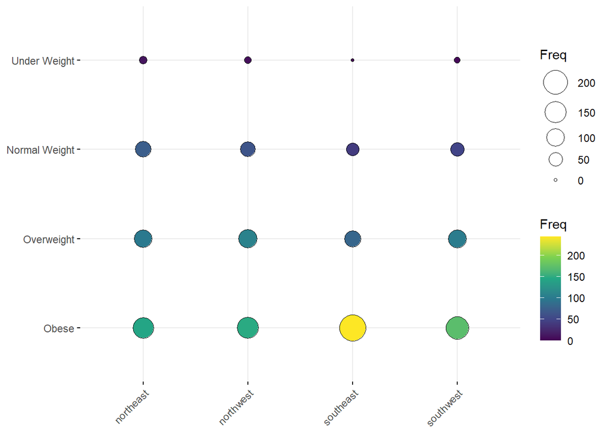

```r
ggpubr::ggballoonplot(as.data.frame(table(dplyr::select(
  insurance_data, region, bmi_cat
))),
fill = "value") +
  scale_fill_viridis_c(option = "D")
```

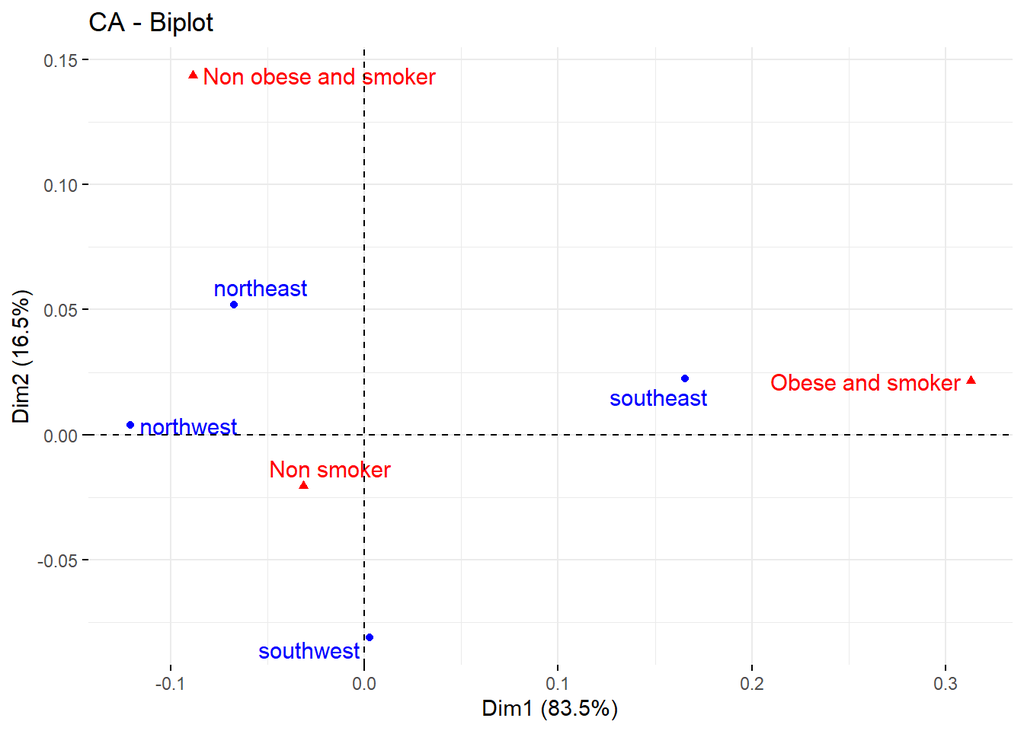

```r
library(FactoMineR)
library(factoextra)
res.ca <-
  CA(table(dplyr::select(insurance_data, region, health)), graph = FALSE)
fviz_ca_biplot(res.ca, repel = TRUE)
```

Grâce aux tableaux de contingence et au graphique ci-dessus, on peut éxpliquer les charges élevés dans le sud-est par la présence d’une proportion importante des patients fumeurs et obèses par rapport aux autres régions.  
et à l’aide du graphe de l’AFC on peut visualiser la dépendance entre les modalités de “health” et “region”, on voit du premier axe qui représente 83.5% de l’information que la région “southeast” se distingue du reste par une dépendance remarquable avec la classe “Obese and smoker”.

## Est ce que le nombre d’enfants de l’assuré influence ses charges ?

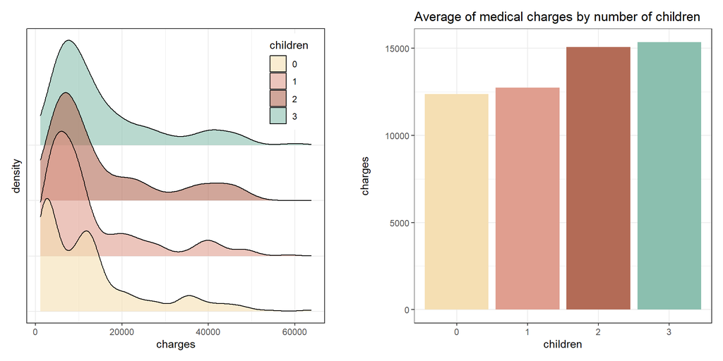

```r
p1 <- ggplot(filter(insurance_data, children %in% c(0:3))) +
  # geom_density(aes(charges,fill = children), alpha = 0.4) +
  # theme(legend.position = c(0.85, 0.78)) +
  # theme(axis.text.y=element_blank(), axis.ticks.y=element_blank())+
  # labs(fill="children\n")
  geom_density_ridges(
    aes(
      x = charges,
      y = children,
      fill = children,
      height = stat(density)
    ),
    alpha=0.6,
    stat = "density",
    scale = 2.25
  ) +
  # alpha = 1,rel_min_height = 0.002, quantile_lines = TRUE) +
  scale_fill_manual(values = c("#f5dfb3","#e09e8f","#b36b56","#8bbfaf")) +
  # scale_x_continuous(expand = c(0, 0)) +
  scale_y_discrete(expand = expand_scale(mult = c(0.07, .7))) +
  coord_cartesian(clip = "off") +
  theme(
    legend.position = c(0.88, 0.82),
    axis.text.y = element_blank(),
    axis.ticks.y = element_blank()
  ) +
  # theme_ridges(font_size = 13, grid = TRUE)+
  labs(y = "density")
p2 <- insurance_data %>%
  ggplot(aes(reorder(children, charges), charges)) +
  geom_bar(
    position = "dodge",
    stat = "summary",
    fun = "mean",
    fill = c("#f5dfb3","#e09e8f","#b36b56","#8bbfaf")
  ) +
  scale_x_discrete(limits = factor(c(0:3))) +
  labs(x = "children", y = "\n\ncharges\n",title="Average of medical charges by number of children")
p1 + p2
```

Les charges sont plus élevés chez les parents.  
Les charges des non parents se caractérisent par une densité particulière.

On va visualiser cette différence avec une nouvelle variable “parent” de deux modalités “yes” et “no”.

```r
insurance_data$parent <-
  as.factor(ifelse(insurance_data$children == 0, "no", "yes"))
```

### Différence entre les charges chez les assurés parents et non parents

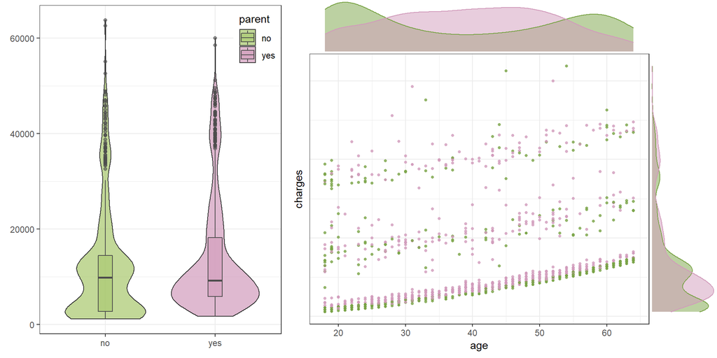

```r
p1 <- insurance_data %>%
  ggplot(aes(y = charges, x = parent, fill = parent)) +
  geom_violin(width = 0.8,alpha=0.7) +
  geom_boxplot(col = "grey30", alpha = 0.6, width = 0.13) +
  theme(legend.position = c(0.9, 0.9)) +
  labs(x = element_blank(), y = element_blank()) +
  scale_fill_manual(values = c("#a7c76c","#d19bbb"))
p <- insurance_data %>%
  ggplot() +
  geom_point(aes(x = age, y = charges, col = parent),
             size = 1,
             alpha = 0.8) +
  scale_color_manual(values=c("#79a346","#d19bbb"))+
  theme(axis.text.y = element_blank(),
        axis.ticks.y = element_blank())

p2 <- ggExtra::ggMarginal(p + theme(legend.position = "none"),

  groupColour = TRUE,
  groupFill = TRUE
)
grid.arrange(p1, p2,
  ncol = 2, widths = c(2, 3)
)
```

La distinction entre les charges des parents et non parents est plus significatif dans le premier niveau.  
La majorité des individus âgés de 30 à 50 ans sont parents, alors que les jeunes et vieillards ne sont pas parents d’enfants couverts par l’assurance.

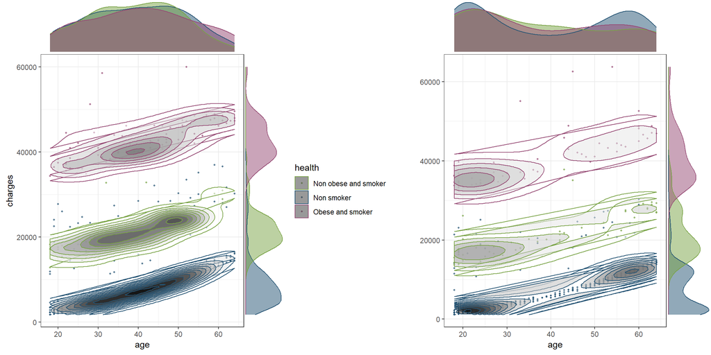

```r
ad <- 0.9
p1 <- insurance_data %>%
  filter(parent == "yes") %>%
  ggplot(aes(x = age, y = charges, col = health)) +
  scale_color_manual(values = c("#79a346", "#245373","#964a74"))+
  geom_point(size = 0.8, alpha = 0.7) +
  stat_density_2d(
    aes(fill = ..level..),
    geom = "polygon",
    alpha = 0.5,
    adjust = ad
  ) +
  labs(fill = "densité\n") +
  scale_fill_gradient(low = "white", high = "black") +
  guides(fill = FALSE, col = FALSE)
p3 <- ggExtra::ggMarginal(p1, groupColour = TRUE, groupFill = TRUE)
p2 <- insurance_data %>%
  filter(parent == "no") %>%
  ggplot(aes(x = age, y = charges, col = health)) +
  geom_point(size = 0.8, alpha = 0.7) +
  scale_color_manual(values = c("#79a346", "#245373","#964a74")) +
  stat_density_2d(
    aes(fill = ..level..),
    geom = "polygon",
    alpha = 0.5,
    adjust = ad
  ) +
  labs(y = "\n") +
  scale_fill_gradient(low = "white", high = "black") +
  guides(fill = FALSE, col = guide_legend(order=1))+
  theme(legend.position = "left")
p4 <- ggExtra::ggMarginal(p2, groupColour = TRUE, groupFill = TRUE)
grid.arrange(p3, p4, nrow = 1, widths = c(6, 9))
```

Due à la relation entre l’âge et les charges :  
Les parents ont des charges centré sur la moyenne de chaque niveau, contrairement aux non parents qui rassemblent à la fois des charges élevés (des plus agés) et des charges bas (des moins agés)  
Cette différence est moins remarquable quand les charges sont élevés à cause de la dominations des charges individuels sur les charges des enfants qui deviennent négligeables.

# Modélisation

## Modéle linéaire

### Initialisation du modèle

On va commencer par un modèle linéaire simple en utilisant les deux variables age et health. Centraliser la variables âge (pour permettre l’interpretation de l’intercept).

```r
insurance_data %<>% mutate(centred_age = age - 18)
```

```r
insurance_data$health = relevel(insurance_data$health, ref = "Non smoker")
mod.basic = lm(charges ~ centred_age + health,
               data = insurance_data,
               x = TRUE,
               y = TRUE)
summary(mod.basic)
```

```
##
## Call:
## lm(formula = charges ~ centred_age + health, data = insurance_data,
##     x = TRUE, y = TRUE)
##
## Residuals:
##     Min      1Q  Median      3Q     Max
## -5585.7 -1953.5 -1324.8  -394.4 24493.8
##
## Coefficients:
##                             Estimate Std. Error t value Pr(>|t|)
## (Intercept)                 2693.654    234.102   11.51   <2e-16 ***
## centred_age                  268.437      8.816   30.45   <2e-16 ***
## healthNon obese and smoker 13343.999    420.794   31.71   <2e-16 ***
## healthObese and smoker     33334.018    401.955   82.93   <2e-16 ***
## ---
## Signif. codes:  0 '***' 0.001 '**' 0.01 '*' 0.05 '.' 0.1 ' ' 1
##
## Residual standard error: 4527 on 1334 degrees of freedom
## Multiple R-squared:  0.8606, Adjusted R-squared:  0.8603
## F-statistic:  2745 on 3 and 1334 DF,  p-value: < 2.2e-16
```

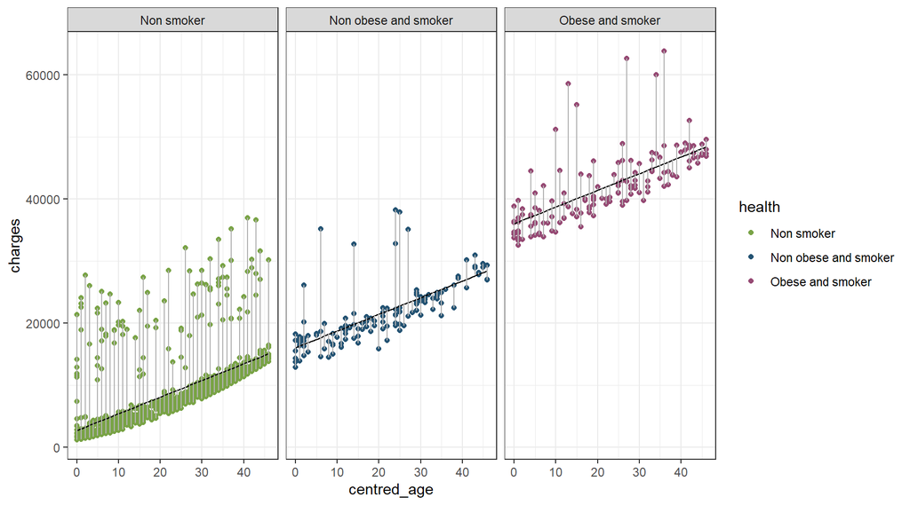

```r
mod.basic %>%
  augment() %>%
  ggplot(aes(x = centred_age, y = charges)) +
  geom_point(aes(col = health)) +
  scale_color_manual(values = c("#79a346", "#245373","#964a74")) +
  geom_line(aes(y = .fitted)) +
  geom_segment(aes(xend = centred_age, yend = .fitted), col = "grey70") +
  facet_grid( ~ health)
```

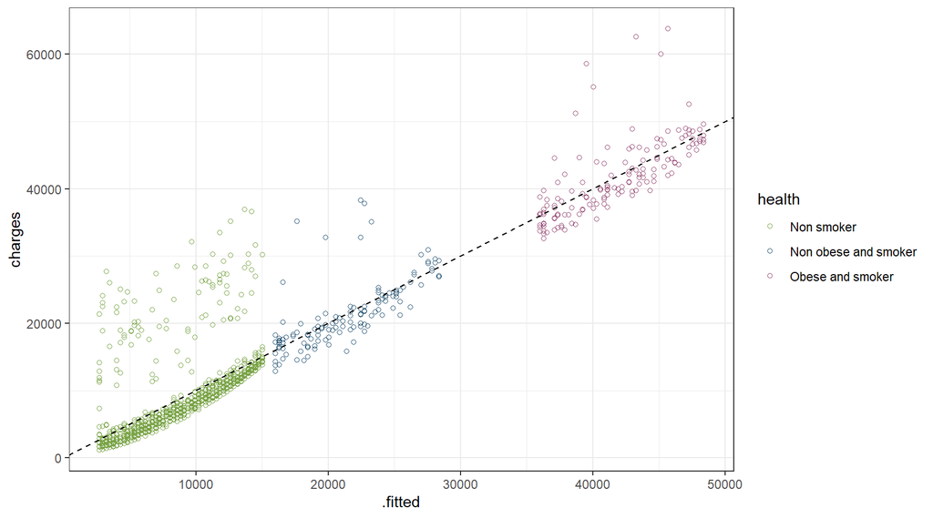

```r
mod.basic %>%
  augment() %>%
  ggplot(aes(x = .fitted, y = charges)) +
  geom_point(shape = 1, aes(col = health)) +
  scale_color_manual(values = c("#79a346", "#245373","#964a74")) +
  geom_abline(slope = 1, lty = "dashed")
```

Sur ce premier modèle:  
- on a obtenu un R-carré ajusté de 0.86, ce qui signifie que 86% de la variation des charges pourrait être expliquée par les deux variables indépendantes age et health.  
- on a également pu observer que toutes les variables indépendantes sont des prédicteurs statistiquement significatifs des frais médicaux (p.value inférieure à 0,05 <- niveau de signification).  
- La moyenne des charges pour un assuré de 18 ans non fumeur est 2693.654.  
- Une année de plus dans l’âge augmente les charges par 268.437 pour la même catégorie de health.  
- Par rapport aux non fumeurs, en contrôlant l’âge :  
Les fumeurs non obèses ont en moyenne 13343.999 plus de charges.  
Les fumeurs obèses ont en moyenne 33334.018 plus de charges.

### Performance du modèle initial :

```r
mod.basic %>%
  glance() %>%
  dplyr::select(r.squared,
         adj.r.squared,
         AIC,
         BIC,
         statistic,
         p.value,
         df.residual,
         nobs) %>%
  knitr::kable(align = "c") %>%
  kableExtra::kable_styling(full_width = F, position = "left")
```

| r.squared | adj.r.squared | AIC | BIC | statistic | p.value | df.residual | nobs |
| --- | --- | --- | --- | --- | --- | --- | --- |
| 0.8605842 | 0.8602707 | 26329.01 | 26355 | 2744.834 | 0 | 1334 | 1338 |

### verification des hypothèses de la régression pour le modèle initial

#### Vérification de la linéarité des données

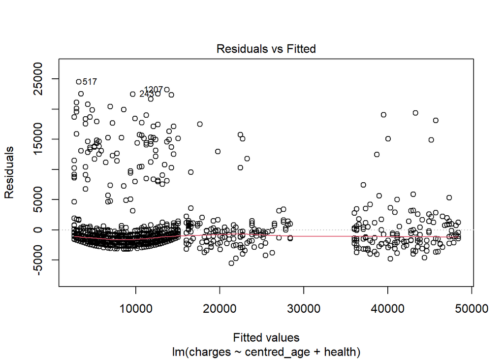

```r
plot(mod.basic, which=1)
```

On peut assumer une relation linéaire entre les prédicteurs et la variable cible.

#### Verification de l’homogénité de la variance par spread-location plot

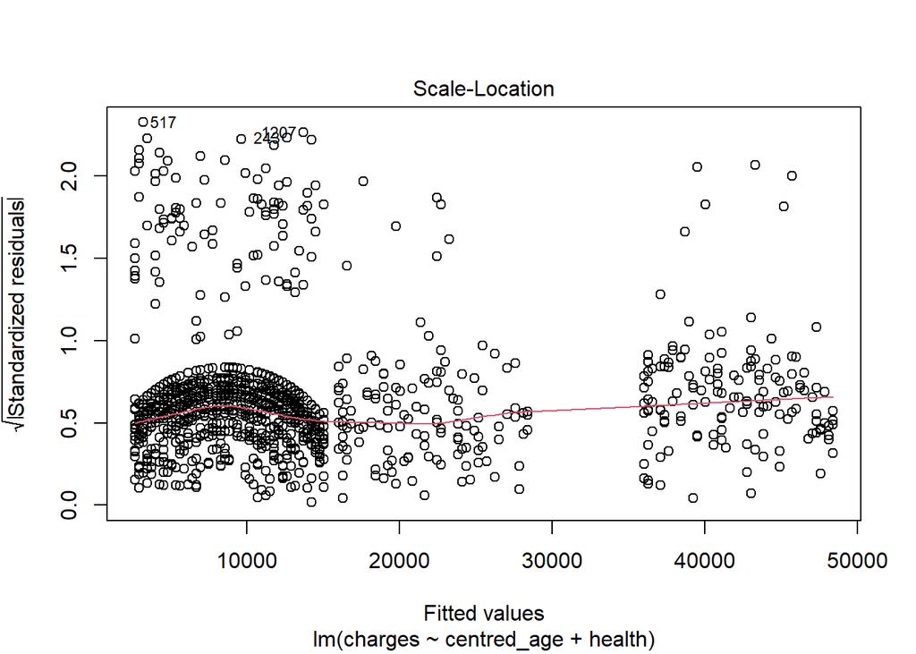

```r
plot(mod.basic, which=3)
```

On costance que la variabilité des résidus en fonction des valeurs prédites a une forme quadratique pour un groupe d’invidus, ce qui indique l’hétéroscédasticité (variances non constantes des erreurs)

ce fait on amène à effectuer une transformation sur la variable âge.

### Amélioration du modèle

```r
mod.age2 = lm(charges ~ I(age ^ 2) + health, data = insurance_data)
summary(mod.age2)
```

```
##
## Call:
## lm(formula = charges ~ I(age^2) + health, data = insurance_data)
##
## Residuals:
##     Min      1Q  Median      3Q     Max
## -4980.7 -1975.6 -1425.1  -264.2 23826.2
##
## Coefficients:
##                             Estimate Std. Error t value Pr(>|t|)
## (Intercept)                2.553e+03  2.368e+02   10.79   <2e-16 ***
## I(age^2)                   3.362e+00  1.098e-01   30.62   <2e-16 ***
## healthNon obese and smoker 1.339e+04  4.199e+02   31.90   <2e-16 ***
## healthObese and smoker     3.331e+04  4.010e+02   83.06   <2e-16 ***
## ---
## Signif. codes:  0 '***' 0.001 '**' 0.01 '*' 0.05 '.' 0.1 ' ' 1
##
## Residual standard error: 4516 on 1334 degrees of freedom
## Multiple R-squared:  0.8612, Adjusted R-squared:  0.8609
## F-statistic:  2760 on 3 and 1334 DF,  p-value: < 2.2e-16
```

Performance :

```r
mod.age2 %>%
  glance() %>%
  dplyr::select(r.squared,
         adj.r.squared,
         AIC,
         BIC,
         statistic,
         p.value,
         df.residual,
         nobs) %>%
  knitr::kable(align = "c") %>%
  kableExtra::kable_styling(full_width = F, position = "left")
```

| r.squared | adj.r.squared | AIC | BIC | statistic | p.value | df.residual | nobs |
| --- | --- | --- | --- | --- | --- | --- | --- |
| 0.8612288 | 0.8609168 | 26322.81 | 26348.8 | 2759.65 | 0 | 1334 | 1338 |

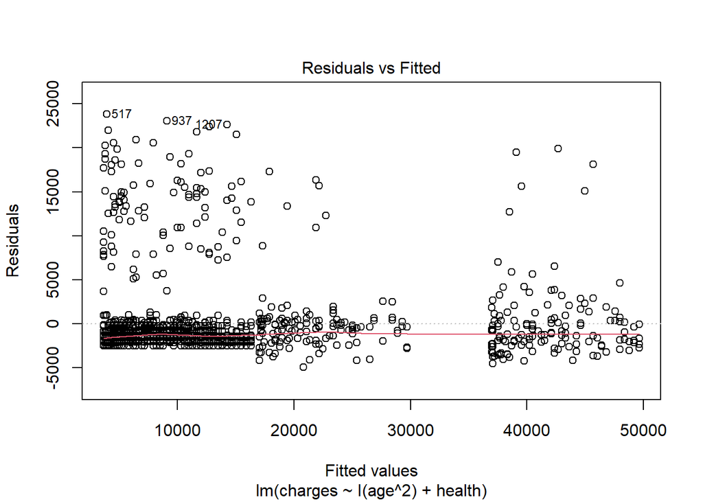

```r
plot(mod.age2, which = 1)
```

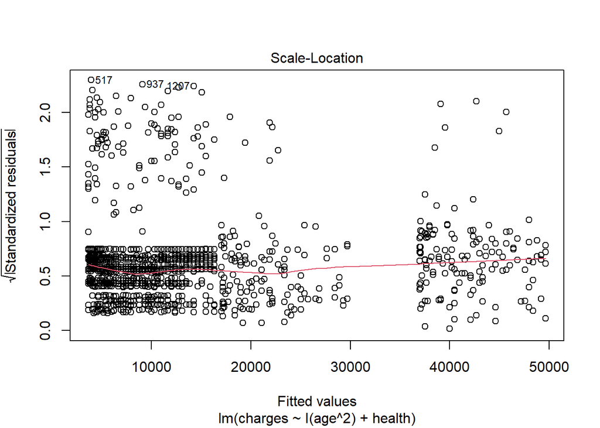

```r
plot(mod.age2, which = 3)
```

On peut assumer que les deux premières hypothèses sont bien vérifiés pour ce deuxième modèle.  
On va essayer d’améliorer encore la précision en ajoutant d’autres variables explicative :

```r
mod.extend = lm(charges ~ I(age ^ 2) + health + smoker:bmi + children + region +
                  sex,
                data = insurance_data)
summary(mod.extend)
```

```
##
## Call:
## lm(formula = charges ~ I(age^2) + health + smoker:bmi + children +
##     region + sex, data = insurance_data)
##
## Residuals:
##    Min     1Q Median     3Q    Max
##  -3271  -1496  -1217   -849  24210
##
## Coefficients:
##                              Estimate Std. Error t value Pr(>|t|)
## (Intercept)                 2189.2344   747.2089   2.930 0.003449 **
## I(age^2)                       3.3456     0.1068  31.322  < 2e-16 ***
## healthNon obese and smoker  1461.1728  1960.6927   0.745 0.456263
## healthObese and smoker     16616.0387  2635.5680   6.305 3.93e-10 ***
## children1                    886.3802   302.7192   2.928 0.003469 **
## children2                   1812.5903   335.3965   5.404 7.71e-08 ***
## children3                   1529.6219   393.1487   3.891 0.000105 ***
## children4                   4098.2667   890.5092   4.602 4.58e-06 ***
## children5                   2174.2555  1046.7760   2.077 0.037985 *
## regionnorthwest             -394.3059   342.6695  -1.151 0.250068
## regionsoutheast             -895.1742   344.7422  -2.597 0.009518 **
## regionsouthwest            -1189.3192   343.6165  -3.461 0.000555 ***
## sexmale                     -522.6149   239.4042  -2.183 0.029213 *
## smokerno:bmi                  14.6839    23.0145   0.638 0.523564
## smokeryes:bmi                486.1988    71.3217   6.817 1.41e-11 ***
## ---
## Signif. codes:  0 '***' 0.001 '**' 0.01 '*' 0.05 '.' 0.1 ' ' 1
##
## Residual standard error: 4352 on 1323 degrees of freedom
## Multiple R-squared:  0.8722, Adjusted R-squared:  0.8708
## F-statistic: 644.8 on 14 and 1323 DF,  p-value: < 2.2e-16
```

En ajoutant d’autres prédicteurs le r-carrée ajustée augmente à 87.08%.

On va tester l’importance des variables sex et region dans la performance du modèle  
H0 : l’ajout de la variable n’a aucune importance

```r
anova(lm(charges ~ I(age ^ 2) + health + smoker:bmi + children + sex , data = insurance_data) ,
      mod.extend)
```

```
## Analysis of Variance Table
##
## Model 1: charges ~ I(age^2) + health + smoker:bmi + children + sex
## Model 2: charges ~ I(age^2) + health + smoker:bmi + children + region +
##     sex
##   Res.Df        RSS Df Sum of Sq      F   Pr(>F)
## 1   1326 2.5326e+10
## 2   1323 2.5062e+10  3 263504216 4.6366 0.003128 **
## ---
## Signif. codes:  0 '***' 0.001 '**' 0.01 '*' 0.05 '.' 0.1 ' ' 1
```

```r
anova(
  lm(charges ~ I(age ^ 2) + health + smoker:bmi + children + region , data = insurance_data) ,
  mod.extend
)
```

```
## Analysis of Variance Table
##
## Model 1: charges ~ I(age^2) + health + smoker:bmi + children + region
## Model 2: charges ~ I(age^2) + health + smoker:bmi + children + region +
##     sex
##   Res.Df        RSS Df Sum of Sq      F  Pr(>F)
## 1   1324 2.5153e+10
## 2   1323 2.5062e+10  1  90273982 4.7654 0.02921 *
## ---
## Signif. codes:  0 '***' 0.001 '**' 0.01 '*' 0.05 '.' 0.1 ' ' 1
```

Avec un niveau de risque 5%, On rejete l’hypothèse H0 pour les deux cas.  
Donc, on garde les deux variables dans le modèle.

### Vérification des hypothèses pour le nouveau modèle amélioré

Linéarité et normalité des résidus:

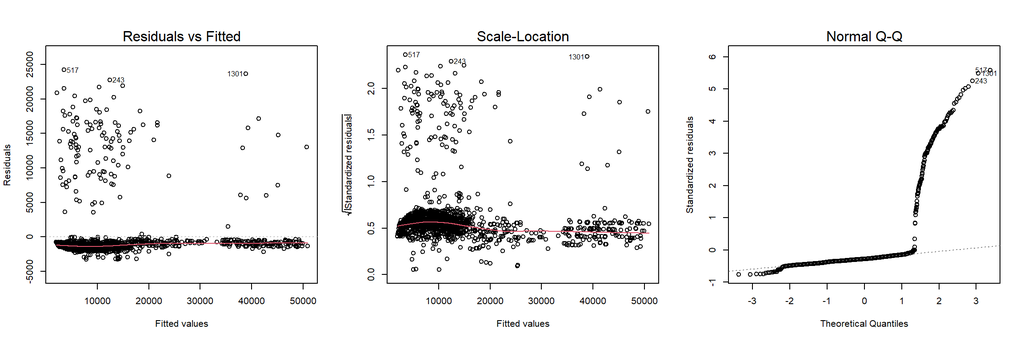

```r
par(mfrow = c(1, 3))
for (i in c(1, 3, 2)) {
  plot(mod.extend, which = i)
}
```

la distribution des résidus n’est pas normale.  
l’hypothèse de linéarité est vérifiée et la variance semble constante, mais on va effectuer un test pour s’assurer.

Hétéroscedasticité:

```r
library(lmtest)
bptest(mod.extend) # tester l'existence de l'hétéroscédasticité lineaire
```

```
##
##  studentized Breusch-Pagan test
##
## data:  mod.extend
## BP = 16.844, df = 14, p-value = 0.2646
```

```r
ncvTest(mod.extend)# tester l'existence de l'hétéroscédasticité non lineaire
```

```
## Non-constant Variance Score Test
## Variance formula: ~ fitted.values
## Chisquare = 8.567156, Df = 1, p = 0.0034228
```

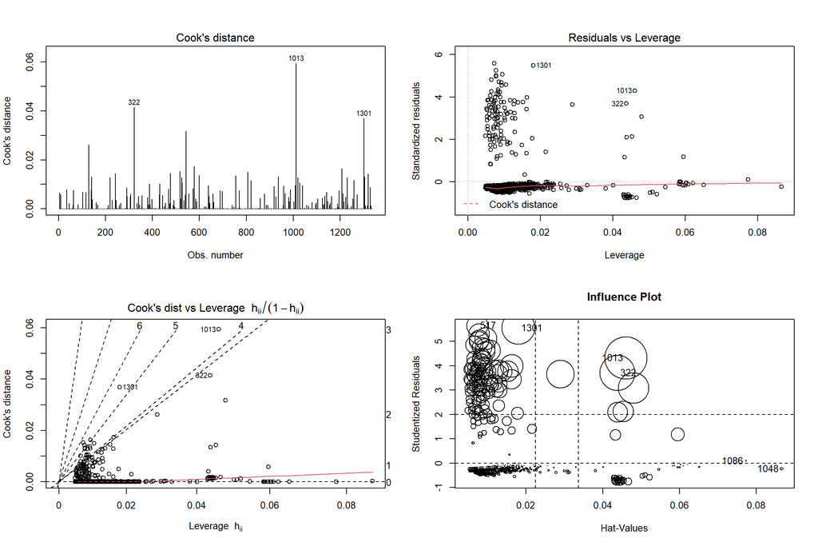

```
##          StudRes         Hat        CookD
## 322   3.70355755 0.043793647 4.148127e-02
## 517   5.64758608 0.007301576 1.528300e-02
## 1013  4.32167210 0.046084448 5.935982e-02
## 1048 -0.22975456 0.086606152 3.339172e-04
## 1086  0.09609113 0.077335829 5.163424e-05
## 1301  5.54943002 0.018034681 3.687613e-02
```

```r
par(mfrow = c(2, 2))
for (i in c(4:6)) {
  plot(mod.extend, which = i)
}
influencePlot(mod.extend, main = "Influence Plot")
```

On a absence de points très influents dans le modèle, malgré l’existence des points ayant un résidu important mais ne sont pas extrêmes par rapport aux prédicteurs, leurs faible hat-values ne leurs permet pas d’influencer la droite de régression, ainsi que des points extrêmes ayant un faible résidu.

les points ayant les plus grandes valeurs de cook’s distance (mesure d’influence basée sur le leverage et le résidu) sont plus caractérisées par un grand résidu (ordre de grandeur > 3) => l’erreur contribue plus dans l’influence de ces points.

```r
perf=mod.extend %>%
  glance() %>%
  dplyr::select(r.squared,
         adj.r.squared,
         AIC,
         BIC,
         statistic,
         p.value,
         df.residual,
         nobs)
perf%>% knitr::kable(align = "c") %>%
        kableExtra::kable_styling(full_width = F, position = "left")
```

| r.squared | adj.r.squared | AIC | BIC | statistic | p.value | df.residual | nobs |
| --- | --- | --- | --- | --- | --- | --- | --- |
| 0.872179 | 0.8708264 | 26234.83 | 26318.01 | 644.8153 | 0 | 1323 | 1338 |

### Contribution des variables dans le modèle :

```r
library(relaimpo)
mod.extend.shapley <-
  calc.relimp(lm(charges ~ I(age ^ 2) + health + bmi + children + region +
                   sex,
                 data = insurance_data),
              type = "lmg")
```

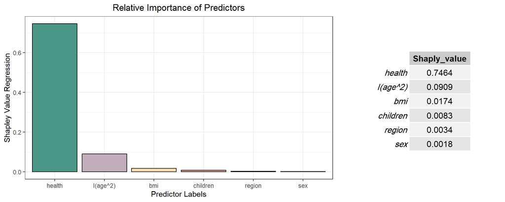

```r
library(caret)
mod.extend.shapley$lmg %>%
  sort(T) %>%
  data.frame()  -> temp
names(temp) <- c("Shaply_value")
p = temp %>%
  cbind(name = rownames(.)) %>%
  ggplot()+
  geom_col(aes(reorder(name, -Shaply_value), Shaply_value), stat = "identity",
           fill = c("#4a9687","#c2aebb","#f5dfb3","#e09e8f","#cfe6b8","#f2d696"), col="black")+
  ggtitle("Relative Importance of Predictors")+
  theme(plot.title = element_text(hjust = 0.5))+
  labs(x="Predictor Labels", y="Shapley Value Regression")
grid.arrange(p ,tableGrob(round(temp,4)), ncol = 2, widths = c(4, 2))
```

Pour dériver l’importance des variables prédicteurs dans ce modèle. on va utiliser une méthode statistique appelée régression des valeurs shapley qui est une solution issue du concept de théorie des jeux. Son objectif est de répartir équitablement l’importance des prédicteurs dans l’analyse de régression. Étant donné n nombre de variables indépendantes (IV), on va exécuter toutes les combinaisons de modèles de régression linéaire en utilisant cette liste de (IV) par rapport à la variable dépendante (DV) et obtenir le R-carré de chaque modèle. Pour obtenir la mesure de l’importance de chaque variable indépendante (IV), la contribution moyenne au R-carré total de chaque (IV) est calculée en décomposant le R-carré total et en calculant la contribution marginale proportionnelle de chaque (IV).

Supposant qu’on a 2 (IV) A et B et une variable dépendante Y. on doit construire 3 modèles comme suit: 1) Y ~ A 2) Y ~ B 3) Y ~ A + B et chaque modèle aurait leur R-carré respectif .

Pour obtenir la valeur Shapley de A, on va décomposer le r-carré du troisième modèle et calculer la contribution marginale de l’attribut A.

Valeur Shapley (A) = $\frac{(R^2 (AB) - R^2 (B)) + R^2 (A)}{2}$

on a utilisé la fonction calc.relimp() du package relaimpo pour déterminer la valeur Shapley de nos prédicteurs.

### Modèle additif généralisé

```r
library(mgcv)
# Build the model
mod.gam <- gam(charges ~ s(age) + health + s(bmi) + children + region +
                 sex,
               data = insurance_data)
summary(mod.gam)
```

```
##
## Family: gaussian
## Link function: identity
##
## Formula:
## charges ~ s(age) + health + s(bmi) + children + region + sex
##
## Parametric coefficients:
##                            Estimate Std. Error t value Pr(>|t|)
## (Intercept)                  8335.7      314.7  26.486  < 2e-16 ***
## healthNon obese and smoker  13603.2      430.7  31.584  < 2e-16 ***
## healthObese and smoker      33216.6      411.2  80.780  < 2e-16 ***
## children1                     970.9      320.6   3.028 0.002508 **
## children2                    1844.7      355.5   5.189 2.44e-07 ***
## children3                    1593.2      408.7   3.899 0.000102 ***
## children4                    4093.3      908.3   4.507 7.17e-06 ***
## children5                    2090.6     1067.6   1.958 0.050414 .
## regionnorthwest              -327.5      347.8  -0.942 0.346553
## regionsoutheast              -786.3      349.2  -2.252 0.024512 *
## regionsouthwest             -1162.8      348.6  -3.335 0.000876 ***
## sexmale                      -481.9      242.5  -1.987 0.047130 *
## ---
## Signif. codes:  0 '***' 0.001 '**' 0.01 '*' 0.05 '.' 0.1 ' ' 1
##
## Approximate significance of smooth terms:
##          edf Ref.df       F p-value
## s(age) 3.083  3.832 246.331  <2e-16 ***
## s(bmi) 3.322  4.206   2.001   0.085 .
## ---
## Signif. codes:  0 '***' 0.001 '**' 0.01 '*' 0.05 '.' 0.1 ' ' 1
##
## R-sq.(adj) =  0.867   Deviance explained = 86.9%
## GCV = 1.9721e+07  Scale est. = 1.945e+07  n = 1338
```

```r
mod.gam %>%
  glance() %>%
  mutate(adj.r.squared = 0.867) %>%
  dplyr::select(adj.r.squared, AIC, BIC, nobs) %>%
  knitr::kable(align = "c") %>%
  kableExtra::kable_styling(full_width = F, position = "left")
```

| adj.r.squared | AIC | BIC | nobs |
| --- | --- | --- | --- |
| 0.867 | 26273.5 | 26374.39 | 1338 |

On n’observe aucune amélioration dans le modele additif généralisé par rapport au modéle précèdent.Donc on préfère le modèle linéaire pour des raisons de simplicité et interpretabilité.

## K-nearest neighbour

### Modèle initial

Afin de pouvoir évaluer le modèle knn, on va diviser notre jeu de données en deux parties : 80% pour le train set, et 20% pour le test set.

```r
set.seed(12345)
insurance_data_split <-
  initial_split(insurance_data, prop = .8, strata = "charges")
insurance_train <- training(insurance_data_split)
insurance_test <- testing(insurance_data_split)
```

A l’aide du package parsnip, On va instancier un modéle knn pour la regression et l’entrainer sur la train set.

```r
library(parsnip)
library(kknn)
model_knn <- nearest_neighbor(mode = "regression") %>%
  set_engine("kknn") %>%
  fit(charges ~ age + bmi + children + health +
        region, data = insurance_train)
```

Puis on va utiliser ce modèle pour effectuer les prédictons sur le test set afin d’évaluer sa performance.

```r
model_knn_pred <- model_knn %>%
  predict(new_data = insurance_test) %>%
  bind_cols(insurance_test %>% dplyr::select(charges))

modelPerform = data.frame(
  RMSE = RMSE(model_knn_pred$.pred, model_knn_pred$charges),
  R2 = R2(model_knn_pred$.pred, model_knn_pred$charges)
)
modelPerform %>%
  knitr::kable(align = "c") %>%
  kableExtra::kable_styling(full_width = F, position = "left")
```

| RMSE | R2 |
| --- | --- |
| 5032.466 | 0.8481833 |

### Amélioration du modèle

Pour améliorer encore plus la performance, on va essayer de trouver le k optimal.

Pour automatiser les prétraitements, on va commencer par créer une recipe pour standariser les variables numeriques age et bmi, et la combiner avec le modèle knn dans un workflow.

```r
#creating recipe
ins_recipe <-
  recipe(charges ~ age + bmi + children + health + region, data = insurance_train) %>%
  step_scale(age, bmi) %>%
  step_center(age, bmi)
#model specification
ins_spec <-
  nearest_neighbor(weight_func = "rectangular", neighbors = tune()) %>%
  set_engine("kknn") %>%
  set_mode("regression")
#workflow(model+recipe)
ins_wf <- workflow() %>%
  add_recipe(ins_recipe) %>%
  add_model(ins_spec)
ins_wf
```

```
## == Workflow ====================================================================
## Preprocessor: Recipe
## Model: nearest_neighbor()
##
## -- Preprocessor ----------------------------------------------------------------
## 2 Recipe Steps
##
## * step_scale()
## * step_center()
##
## -- Model -----------------------------------------------------------------------
## K-Nearest Neighbor Model Specification (regression)
##
## Main Arguments:
##   neighbors = tune()
##   weight_func = rectangular
##
## Computational engine: kknn
```

Pour trouver le k optimale pour le modèle, on va utiliser la méthode de validation du cross-fold avec 5 folds, qui sert à diviser les données sur cinq partie, et à chaque itération réserver une partie pour la validation et utiliser les autres pour l’entrainement, puis calculer la performance en utilisant la moyenne des perfarmances sur les différents folds.

Ici on va chercher le k optimale dans l’intervalle [1,100], et mesurer la performance avec cross-fold validation pour réduire l’erreur due à l’interaction possible entre les variables lors d’une simple division.

```r
set.seed(123456)
ins_vfold <- vfold_cv(insurance_train, v = 5, strata = charges)

gridvals <- tibble(neighbors = seq(1, 100))

ins_results <- ins_wf %>%
  tune_grid(resamples = ins_vfold, grid = gridvals) %>%
  collect_metrics()

ins_results  %>%
  knitr::kable(align = "c") %>%
  kableExtra::kable_styling(full_width = T, position = "left")  %>%
  kableExtra::kable_paper() %>%
  kableExtra::scroll_box( height = "300px")
```

| neighbors | .metric | .estimator | mean | n | std_err | .config |
| --- | --- | --- | --- | --- | --- | --- |
| 1 | rmse | standard | 6178.9140580 | 5 | 173.3195772 | Preprocessor1_Model001 |
| 1 | rsq | standard | 0.7523178 | 5 | 0.0152306 | Preprocessor1_Model001 |
| 2 | rmse | standard | 5287.3902576 | 5 | 182.8131372 | Preprocessor1_Model002 |
| 2 | rsq | standard | 0.8068960 | 5 | 0.0170376 | Preprocessor1_Model002 |
| 3 | rmse | standard | 5100.9016560 | 5 | 202.0380177 | Preprocessor1_Model003 |
| 3 | rsq | standard | 0.8185064 | 5 | 0.0169442 | Preprocessor1_Model003 |
| 4 | rmse | standard | 4963.0848913 | 5 | 227.1004810 | Preprocessor1_Model004 |
| 4 | rsq | standard | 0.8269390 | 5 | 0.0187191 | Preprocessor1_Model004 |
| 5 | rmse | standard | 4890.3112905 | 5 | 253.3037270 | Preprocessor1_Model005 |
| 5 | rsq | standard | 0.8315022 | 5 | 0.0196675 | Preprocessor1_Model005 |
| 6 | rmse | standard | 4851.6850923 | 5 | 255.4585673 | Preprocessor1_Model006 |
| 6 | rsq | standard | 0.8336937 | 5 | 0.0195599 | Preprocessor1_Model006 |
| 7 | rmse | standard | 4775.7779870 | 5 | 252.4518214 | Preprocessor1_Model007 |
| 7 | rsq | standard | 0.8392938 | 5 | 0.0185528 | Preprocessor1_Model007 |
| 8 | rmse | standard | 4773.4450843 | 5 | 255.8713731 | Preprocessor1_Model008 |
| 8 | rsq | standard | 0.8396510 | 5 | 0.0185616 | Preprocessor1_Model008 |
| 9 | rmse | standard | 4733.5640708 | 5 | 256.0109169 | Preprocessor1_Model009 |
| 9 | rsq | standard | 0.8427674 | 5 | 0.0180070 | Preprocessor1_Model009 |
| 10 | rmse | standard | 4715.0323446 | 5 | 263.7646139 | Preprocessor1_Model010 |
| 10 | rsq | standard | 0.8437694 | 5 | 0.0184588 | Preprocessor1_Model010 |
| 11 | rmse | standard | 4693.7602162 | 5 | 264.6281078 | Preprocessor1_Model011 |
| 11 | rsq | standard | 0.8450957 | 5 | 0.0183661 | Preprocessor1_Model011 |
| 12 | rmse | standard | 4675.7965036 | 5 | 266.1327002 | Preprocessor1_Model012 |
| 12 | rsq | standard | 0.8460284 | 5 | 0.0184862 | Preprocessor1_Model012 |
| 13 | rmse | standard | 4658.2517213 | 5 | 264.0859288 | Preprocessor1_Model013 |
| 13 | rsq | standard | 0.8470701 | 5 | 0.0183785 | Preprocessor1_Model013 |
| 14 | rmse | standard | 4653.9054267 | 5 | 267.4354491 | Preprocessor1_Model014 |
| 14 | rsq | standard | 0.8472995 | 5 | 0.0184257 | Preprocessor1_Model014 |
| 15 | rmse | standard | 4649.7572197 | 5 | 274.8265877 | Preprocessor1_Model015 |
| 15 | rsq | standard | 0.8474079 | 5 | 0.0189709 | Preprocessor1_Model015 |

[output cut: 170 more lines]

En comparant le RMSE pour les différents k,on peut constater que si on prend trop ou très peu de voisins, nous obtenons une faible précision.

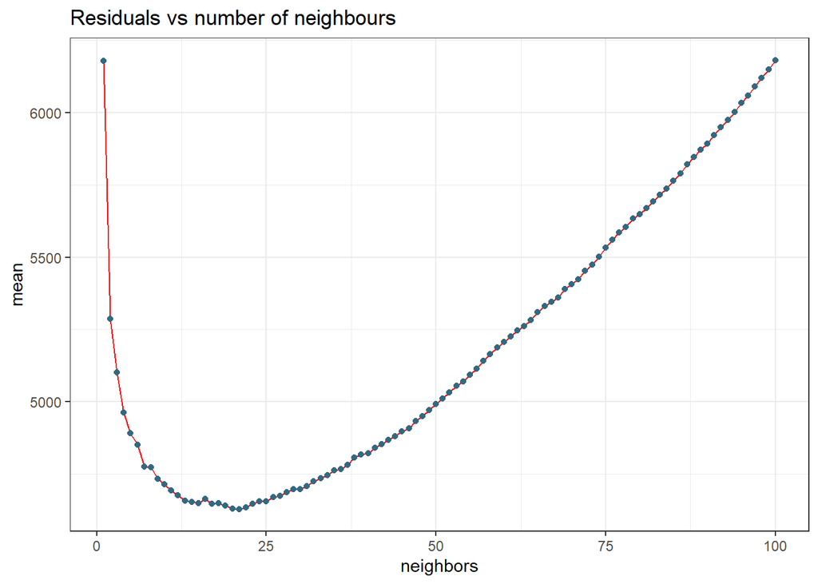

```r
ins_results %>%
  filter(.metric == "rmse") %>%
  ggplot(aes(neighbors, mean)) +
  geom_line(col="red") +
  geom_point(col = "#336980")+
  labs(title="Residuals vs number of neighbours")
```

```r
ins_min <- ins_results %>%
  filter(.metric == "rmse") %>%
  filter(mean == min(mean))
ins_min %>%
  knitr::kable(align = "c") %>%
  kableExtra::kable_styling(full_width = F, position = "left")
```

| neighbors | .metric | .estimator | mean | n | std_err | .config |
| --- | --- | --- | --- | --- | --- | --- |
| 21 | rmse | standard | 4629.166 | 5 | 260.0895 | Preprocessor1_Model021 |

```r
kmin <- ins_min %>% pull(neighbors)
```

maintenant on va re-entrainer notre modèle avec la valeur optimale de k=21, et évaluer sa performance.

```r
set.seed(123456)
ins_spec <-
  nearest_neighbor(weight_func = "rectangular", neighbors = kmin) %>%
  set_engine("kknn") %>%
  set_mode("regression")

ins_fit <- workflow() %>%
  add_recipe(ins_recipe) %>%
  add_model(ins_spec) %>%
  fit(data = insurance_train)
ins_fit
```

```
## == Workflow [trained] ==========================================================
## Preprocessor: Recipe
## Model: nearest_neighbor()
##
## -- Preprocessor ----------------------------------------------------------------
## 2 Recipe Steps
##
## * step_scale()
## * step_center()
##
## -- Model -----------------------------------------------------------------------
##
## Call:
## kknn::train.kknn(formula = ..y ~ ., data = data, ks = min_rows(21L,     data, 5), kernel = ~"rectangular")
##
## Type of response variable: continuous
## minimal mean absolute error: 2614.916
## Minimal mean squared error: 21519995
## Best kernel: rectangular
## Best k: 21
```

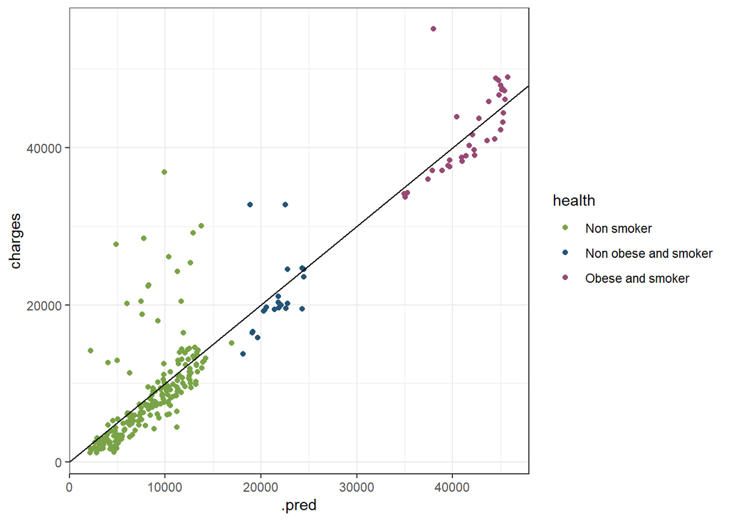

```r
ins_res <- ins_fit %>%
  predict(insurance_test) %>%
  bind_cols(insurance_test)

ins_res %>%  ggplot(aes(y = charges, x = .pred, col = health)) +
  geom_point() +
  scale_color_manual(values = c("#79a346", "#245373","#964a74")) +
  geom_abline(slope = 1)
```

```r
ins_summary <- ins_res %>%
  metrics(truth = charges, estimate = .pred)

ins_summary %>%
  knitr::kable(align = "c") %>%
  kableExtra::kable_styling(full_width = F, position = "left")
```

| .metric | .estimator | .estimate |
| --- | --- | --- |
| rmse | standard | 4642.8788742 |
| rsq | standard | 0.8698845 |
| mae | standard | 2675.5606994 |

## Random forest

### Modèl initial

On va commencer par entrainer un modèle de “random forest” sur le training-set en utilisant l’ensemble des variables et en gardant les paramètres par défaut qu’on va évaluer sur le test-set.

```r
library(randomForest)
model_rand_forest <- rand_forest(mode = "regression") %>%
  set_engine("randomForest") %>%
  fit(charges ~ age + bmi + children + health +
        region + sex, data = insurance_train)
```

```r
model_rand_forest_pred <- model_rand_forest %>%
  predict(new_data = insurance_test) %>%
  bind_cols(insurance_test %>% dplyr::select(charges))
model_rand_forest_pred %>%
  knitr::kable(align = "c") %>%
  kableExtra::kable_styling(full_width = F, position = "left")  %>%
  # kableExtra::kable_paper() %>%
  kableExtra::scroll_box(width = "230px", height = "300px")
```

| .pred | charges |
| --- | --- |
| 10451.433 | 6406.411 |
| 3660.008 | 2198.190 |
| 6335.282 | 4687.797 |
| 2650.023 | 1625.434 |
| 5255.351 | 3046.062 |
| 5914.029 | 4949.759 |
| 7127.264 | 6313.759 |
| 8745.097 | 6079.672 |
| 24201.908 | 23568.272 |
| 37416.161 | 37742.576 |
| 45024.699 | 47496.494 |
| 8077.114 | 5989.524 |
| 3122.390 | 1743.214 |
| 7023.986 | 5920.104 |
| 19461.594 | 16577.780 |
| 3258.499 | 1532.470 |
| 22657.791 | 21098.554 |
| 12131.086 | 8026.667 |
| 17818.219 | 15820.699 |
| 6291.896 | 5003.853 |
| 6277.419 | 4646.759 |
| 12104.121 | 11488.317 |
| 2753.991 | 1705.624 |
| 4696.097 | 3385.399 |
| 16312.455 | 32734.186 |
| 8002.223 | 6082.405 |
| 13703.279 | 12815.445 |
| 3901.848 | 2457.211 |
| 3712.193 | 1842.519 |
| 21616.845 | 19964.746 |

[output cut: 234 more lines]

```r
modelPerform_rand_forest = data.frame(
  RMSE = RMSE(
    model_rand_forest_pred$.pred,
    model_rand_forest_pred$charges
  ),
  R2 = R2(
    model_rand_forest_pred$.pred,
    model_rand_forest_pred$charges
  )
)
modelPerform_rand_forest %>%
  knitr::kable(align = "c") %>%
  kableExtra::kable_styling(full_width = F, position = "left")
```

| RMSE | R2 |
| --- | --- |
| 4720.893 | 0.8689894 |

### Amélioration du modèle

On va essayer maintenant d’améliorer ces performances en réglant les hyperparamètres min_n(nombre minimale d’observations requis dans un noeud pour le diviser) et mtry(Le nombre de prédicteurs qui seront échantillonnés au hasard à chaque division lors de la création des modèles d’arbre).

Pour automatiser les prétraitements, on va utiliser une recipe pour centrer et réduire les variables numeriques age et bmi, et la combiner avec la spécification du modèle dans un workflow.

```r
#creating recipe
ins_recipe2 <-
  recipe(charges ~ age + bmi + children + health + region + sex, data = insurance_train) %>%
  step_scale(age, bmi) %>%
  step_center(age, bmi)
#model specification
ins_spec_rf <- rand_forest(min_n = tune(),mtry=tune()) %>%
  set_engine("randomForest") %>%
  set_mode("regression")
#workflow(model+recipe)
ins_wf_rf <- workflow() %>%
  add_recipe(ins_recipe2) %>%
  add_model(ins_spec_rf)
ins_wf_rf
```

```
## == Workflow ====================================================================
## Preprocessor: Recipe
## Model: rand_forest()
##
## -- Preprocessor ----------------------------------------------------------------
## 2 Recipe Steps
##
## * step_scale()
## * step_center()
##
## -- Model -----------------------------------------------------------------------
## Random Forest Model Specification (regression)
##
## Main Arguments:
##   mtry = tune()
##   min_n = tune()
##
## Computational engine: randomForest
```

Tuning des hyperparamètres :  
On va utiliser la méthode “Grid search” Pour pouvoir trouver la combinaison optimale des hyperparamètres “mtry” et “min_n”.

```r
set.seed(123456)

ins_results_rf_grid <- ins_wf_rf %>%
  tune_grid(resamples = ins_vfold, grid = data_grid)

ins_results_rf <- ins_results_rf_grid%>%
  collect_metrics()

ins_results_rf %>%
  knitr::kable(align = "c") %>%
  kableExtra::kable_styling(full_width = T, position = "left")  %>%
  kableExtra::kable_paper() %>%
  kableExtra::scroll_box( height = "300px")
```

| mtry | min_n | .metric | .estimator | mean | n | std_err | .config |
| --- | --- | --- | --- | --- | --- | --- | --- |
| 3 | 26 | rmse | standard | 4502.9713269 | 5 | 246.9508460 | Preprocessor1_Model01 |
| 3 | 26 | rsq | standard | 0.8572369 | 5 | 0.0178017 | Preprocessor1_Model01 |
| 4 | 26 | rmse | standard | 4486.3605136 | 5 | 247.3486272 | Preprocessor1_Model02 |
| 4 | 26 | rsq | standard | 0.8575817 | 5 | 0.0176938 | Preprocessor1_Model02 |
| 5 | 26 | rmse | standard | 4507.6436824 | 5 | 241.7663073 | Preprocessor1_Model03 |
| 5 | 26 | rsq | standard | 0.8565050 | 5 | 0.0174662 | Preprocessor1_Model03 |
| 6 | 26 | rmse | standard | 4540.8392467 | 5 | 238.8689672 | Preprocessor1_Model04 |
| 6 | 26 | rsq | standard | 0.8547268 | 5 | 0.0173503 | Preprocessor1_Model04 |
| 3 | 28 | rmse | standard | 4492.4823224 | 5 | 246.0261177 | Preprocessor1_Model05 |
| 3 | 28 | rsq | standard | 0.8579409 | 5 | 0.0174977 | Preprocessor1_Model05 |
| 4 | 28 | rmse | standard | 4480.4196667 | 5 | 248.8713755 | Preprocessor1_Model06 |
| 4 | 28 | rsq | standard | 0.8579075 | 5 | 0.0178142 | Preprocessor1_Model06 |
| 5 | 28 | rmse | standard | 4506.2273528 | 5 | 242.0233731 | Preprocessor1_Model07 |
| 5 | 28 | rsq | standard | 0.8565265 | 5 | 0.0174745 | Preprocessor1_Model07 |
| 6 | 28 | rmse | standard | 4531.7370785 | 5 | 240.9903022 | Preprocessor1_Model08 |
| 6 | 28 | rsq | standard | 0.8551576 | 5 | 0.0174482 | Preprocessor1_Model08 |
| 3 | 30 | rmse | standard | 4502.4015236 | 5 | 253.0207005 | Preprocessor1_Model09 |
| 3 | 30 | rsq | standard | 0.8572583 | 5 | 0.0180438 | Preprocessor1_Model09 |
| 4 | 30 | rmse | standard | 4480.9065073 | 5 | 252.5024903 | Preprocessor1_Model10 |
| 4 | 30 | rsq | standard | 0.8577283 | 5 | 0.0179642 | Preprocessor1_Model10 |
| 5 | 30 | rmse | standard | 4504.6791618 | 5 | 247.8567109 | Preprocessor1_Model11 |
| 5 | 30 | rsq | standard | 0.8565087 | 5 | 0.0178983 | Preprocessor1_Model11 |
| 6 | 30 | rmse | standard | 4531.1114752 | 5 | 241.6965059 | Preprocessor1_Model12 |
| 6 | 30 | rsq | standard | 0.8551242 | 5 | 0.0174564 | Preprocessor1_Model12 |
| 3 | 32 | rmse | standard | 4499.8684604 | 5 | 249.1454239 | Preprocessor1_Model13 |
| 3 | 32 | rsq | standard | 0.8574502 | 5 | 0.0178746 | Preprocessor1_Model13 |
| 4 | 32 | rmse | standard | 4485.3582706 | 5 | 254.1382742 | Preprocessor1_Model14 |
| 4 | 32 | rsq | standard | 0.8573791 | 5 | 0.0181175 | Preprocessor1_Model14 |
| 5 | 32 | rmse | standard | 4499.0556140 | 5 | 249.3251531 | Preprocessor1_Model15 |
| 5 | 32 | rsq | standard | 0.8567260 | 5 | 0.0178276 | Preprocessor1_Model15 |
| 6 | 32 | rmse | standard | 4517.2728936 | 5 | 246.0942965 | Preprocessor1_Model16 |
| 6 | 32 | rsq | standard | 0.8558118 | 5 | 0.0176314 | Preprocessor1_Model16 |
| 3 | 34 | rmse | standard | 4494.1781361 | 5 | 247.5034820 | Preprocessor1_Model17 |
| 3 | 34 | rsq | standard | 0.8579955 | 5 | 0.0177320 | Preprocessor1_Model17 |
| 4 | 34 | rmse | standard | 4477.2679787 | 5 | 252.1122315 | Preprocessor1_Model18 |
| 4 | 34 | rsq | standard | 0.8578414 | 5 | 0.0179604 | Preprocessor1_Model18 |
| 5 | 34 | rmse | standard | 4498.0367395 | 5 | 255.1573410 | Preprocessor1_Model19 |
| 5 | 34 | rsq | standard | 0.8565994 | 5 | 0.0183137 | Preprocessor1_Model19 |
| 6 | 34 | rmse | standard | 4519.5092097 | 5 | 249.7806274 | Preprocessor1_Model20 |
| 6 | 34 | rsq | standard | 0.8555612 | 5 | 0.0179683 | Preprocessor1_Model20 |
| 3 | 36 | rmse | standard | 4498.9937117 | 5 | 253.1112587 | Preprocessor1_Model21 |
| 3 | 36 | rsq | standard | 0.8575007 | 5 | 0.0180595 | Preprocessor1_Model21 |
| 4 | 36 | rmse | standard | 4482.6950210 | 5 | 257.3142287 | Preprocessor1_Model22 |
| 4 | 36 | rsq | standard | 0.8575048 | 5 | 0.0183140 | Preprocessor1_Model22 |
| 5 | 36 | rmse | standard | 4493.8055794 | 5 | 253.7648297 | Preprocessor1_Model23 |
| 5 | 36 | rsq | standard | 0.8568971 | 5 | 0.0181862 | Preprocessor1_Model23 |
| 6 | 36 | rmse | standard | 4519.1213683 | 5 | 250.4609414 | Preprocessor1_Model24 |
| 6 | 36 | rsq | standard | 0.8555345 | 5 | 0.0180142 | Preprocessor1_Model24 |
| 3 | 38 | rmse | standard | 4518.8059165 | 5 | 249.9243199 | Preprocessor1_Model25 |
| 3 | 38 | rsq | standard | 0.8566750 | 5 | 0.0179041 | Preprocessor1_Model25 |
| 4 | 38 | rmse | standard | 4486.1647083 | 5 | 257.0999480 | Preprocessor1_Model26 |
| 4 | 38 | rsq | standard | 0.8571813 | 5 | 0.0182885 | Preprocessor1_Model26 |
| 5 | 38 | rmse | standard | 4498.2283354 | 5 | 252.1359709 | Preprocessor1_Model27 |
| 5 | 38 | rsq | standard | 0.8564944 | 5 | 0.0180877 | Preprocessor1_Model27 |
| 6 | 38 | rmse | standard | 4517.3020586 | 5 | 253.0717244 | Preprocessor1_Model28 |
| 6 | 38 | rsq | standard | 0.8554945 | 5 | 0.0182853 | Preprocessor1_Model28 |

Visualisation de l’erreur pour les combinaisons de “mtry” et “min_n” :

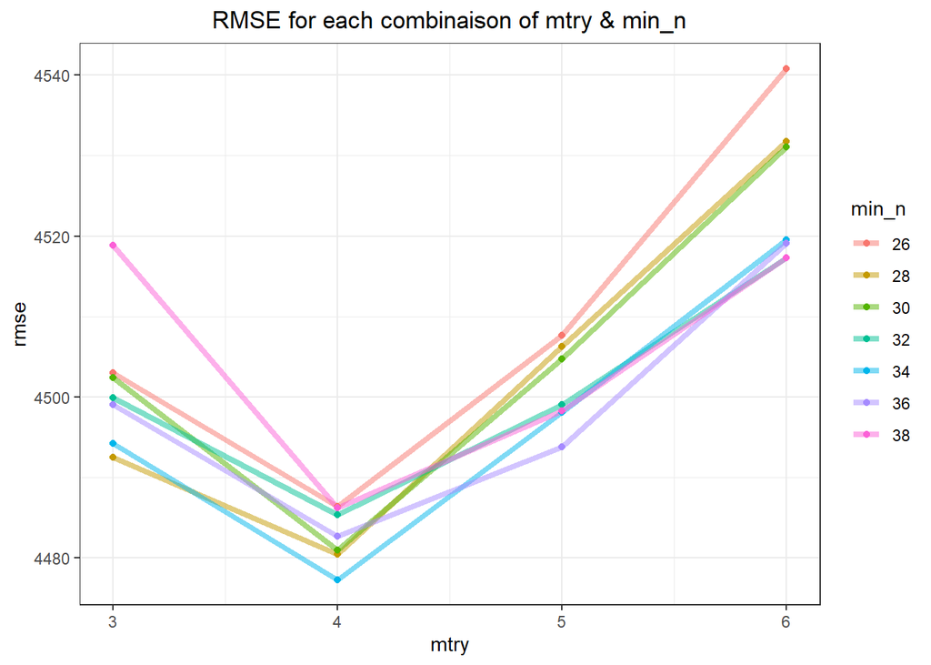

```r
ins_results_rf %>%
  filter(.metric == "rmse") %>%
  mutate(min_n = factor(min_n)) %>%
  ggplot(aes(x=mtry, y=mean,col=min_n)) +
  geom_line(alpha = 0.5, size = 1.5) +
  geom_point() +
  labs(title="RMSE for each combinaison of mtry & min_n",y = "rmse")+
  theme(plot.title = element_text(hjust = 0.5))
```

finalement, on va choisir les meilleurs hyper-paramètres pour notre modèle, puis mettre à jour la spécification du modèle d’origine pour créer la spécification de modèle finale.

```r
best_param <- ins_results_rf %>%
  filter(.metric == "rmse") %>%
  filter(mean == min(mean))
best_param %>%
  knitr::kable(align = "c") %>%
  kableExtra::kable_styling(full_width = F, position = "left")
```

| mtry | min_n | .metric | .estimator | mean | n | std_err | .config |
| --- | --- | --- | --- | --- | --- | --- | --- |
| 4 | 34 | rmse | standard | 4477.268 | 5 | 252.1122 | Preprocessor1_Model18 |

```r
best_mtry <- best_param %>% pull(mtry)
best_min_n <- best_param %>% pull(min_n)
```

```r
best_rmse <- select_best(ins_results_rf_grid,"rmse")
final_rf <- finalize_model(
  ins_spec_rf,
  best_rmse
)
final_rf
```

```
## Random Forest Model Specification (regression)
##
## Main Arguments:
##   mtry = 4
##   min_n = 34
##
## Computational engine: randomForest
```

Les hyper-paramètres optimaux sont mtry = 4 et min_n = 34 .

```r
last_fit(final_rf, charges~age + bmi + children + health + region + sex, insurance_data_split) %>%
  collect_metrics() %>%
  knitr::kable(align = "c") %>%
  kableExtra::kable_styling(full_width = F, position = "left")
```

| .metric | .estimator | .estimate | .config |
| --- | --- | --- | --- |
| rmse | standard | 4596.2229943 | Preprocessor1_Model1 |
| rsq | standard | 0.8724205 | Preprocessor1_Model1 |

L’optimisation des hyperparamètres a amélioré les preformance,

```r
model_final_rf <- rand_forest(mode = "regression",mtry=best_mtry,min_n = best_min_n) %>%
  set_engine("randomForest") %>%
  fit(charges ~ age + bmi + children + health +region + sex, data = insurance_train)
```

```r
model_final_rf_pred <- model_final_rf %>%
  predict(new_data = insurance_test) %>%
  bind_cols(insurance_test %>% dplyr::select(charges))
model_final_rf_pred %>%
  knitr::kable(align = "c") %>%
  kableExtra::kable_styling(full_width = F, position = "left")  %>%
  # kableExtra::kable_paper() %>%
  kableExtra::scroll_box(width = "230px", height = "300px")
```

| .pred | charges |
| --- | --- |
| 9313.516 | 6406.411 |
| 2825.881 | 2198.190 |
| 6488.111 | 4687.797 |
| 2035.577 | 1625.434 |
| 5258.149 | 3046.062 |
| 5496.489 | 4949.759 |
| 7100.562 | 6313.759 |
| 8053.543 | 6079.672 |
| 25660.807 | 23568.272 |
| 38533.203 | 37742.576 |
| 46657.647 | 47496.494 |
| 7361.800 | 5989.524 |
| 2720.721 | 1743.214 |
| 7055.363 | 5920.104 |
| 18660.887 | 16577.780 |
| 2589.512 | 1532.470 |
| 23737.523 | 21098.554 |
| 11330.600 | 8026.667 |
| 17857.613 | 15820.699 |
| 5998.075 | 5003.853 |
| 6289.880 | 4646.759 |
| 13072.438 | 11488.317 |
| 2343.480 | 1705.624 |
| 4775.943 | 3385.399 |
| 16957.235 | 32734.186 |
| 7062.731 | 6082.405 |
| 13898.893 | 12815.445 |
| 3267.267 | 2457.211 |
| 3034.871 | 1842.519 |
| 23232.219 | 19964.746 |

[output cut: 234 more lines]

```r
modelPerform_model_final = data.frame(
  RMSE = RMSE(
    model_final_rf_pred$.pred,
    model_final_rf_pred$charges
  ),
  R2 = R2(
    model_final_rf_pred$.pred,
    model_final_rf_pred$charges
  )
)
modelPerform_model_final %>%
  knitr::kable(align = "c") %>%
  kableExtra::kable_styling(full_width = F, position = "left")
```

| RMSE | R2 |
| --- | --- |
| 4607.556 | 0.8717825 |

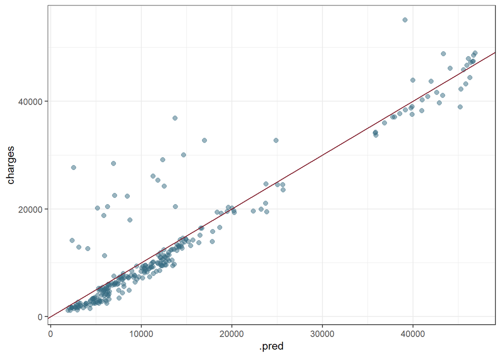

```r
model_final_rf_pred %>%  ggplot(aes(y = charges, x = .pred)) +
  geom_point(col="#336980",size=2,alpha=0.5) +
  geom_abline(slope = 1,col="#821f2e")
```

## Comparaison des modèles

```r
result_linear_mod = predict(mod.extend, insurance_data)
lm_rmse = RMSE(result_linear_mod, insurance_data$charges)
lm_rsq = perf %>% pull(r.squared)
knn_rmse = ins_summary %>% filter(.metric == "rmse") %>% pull(.estimate)
knn_rsq = ins_summary %>% filter(.metric == "rsq") %>% pull(.estimate)
rf_rsq = modelPerform_model_final %>% pull(R2)
rf_rmse = modelPerform_model_final %>% pull(RMSE)

model <- c("Linear model", "KNN", "Random forest")
R_squared <- c(lm_rsq, knn_rsq, rf_rsq)
RMSE <- c(lm_rmse, knn_rmse, rf_rmse)

data.frame(model, R_squared, RMSE) %>%
  knitr::kable(align = "c") %>%
  kableExtra::kable_styling(full_width = F, position = "left")
```

| model | R_squared | RMSE |
| --- | --- | --- |
| Linear model | 0.8721790 | 4327.960 |
| KNN | 0.8698845 | 4642.879 |
| Random forest | 0.8717825 | 4607.556 |

# Conclusion

Les trois modèles permettent d’atteindre presque la même précision, mais on a un grand avantage de l’interprétabilité dans le modèle linéaire.  
Pour obtenir encore plus de précision dans ses prédiction, on propose à cette assurance de collecter plus de données sur ses clients afin d’expliquer le comportement de certain individus qu’on a remarquer -dans la phase de visualisation- qu’ils ne suivent pas la même tendance des autres.  
Si, même après l’étude, on n’a pas arriver à distinguer ces observations du reste de la population on doit pensée à utiliser des modéles dédiés à ce problème, principalement RLM Robust Linear model qui donne un poid faibles aux points influenceurs.